# Exploratory Data Analysis

shobha mourya

March 3, 2019

# 1 Exploratory Data Analysis

## 1.1 EDA: Categorical Data

To create graphical and numerical summaries of two categorical variables

1. Bar chart expectations
2. Contingency table review
3. Dropping levels
4. Side-by-side barcharts
5. Bar chart interpretation
6. counts vs. proportions
7. conditional proportions
8. distribution of one variable
9. marginal barchart
10. conditional barchart
11. improve piechart

## 1.2 EDA: Numerical Data

To graphically summarize numerical data

1. Faceted histogram
2. Boxplots and density plots
3. Compare distribution via plots
4. Distribution of one variable
5. Marginal and conditional histograms
6. Margincal and conditional histograms interpretation
7. Three binwidths
8. Three binwidths interpretation
9. Box plots
10. Box plots for outliers
11. Plot selection
12. Visualization in higher dimensions
13. 3 variable plot
14. Interpret 3 var plot

## 1.3 Numerical Summaries: Measures of center and Measures of spread

Some useful statistics for describing distribution of data

1. Measures of center
2. Choice of center measure
3. Calculate center measures
4. Measures of variability
5. Choice of spread measure
6. Calculate spread measures
7. Choose measures for center and spread
8. Shape and transformations
9. Describe the shape
10. Transformations
11. Outliers
12. Identify outliers

# 2 Load the libraries and datasets

```r
library(readr)
```

```r
library(ggplot2)
library(dplyr)
path = "C:/Users/shobha/Documents/RExploratyDataAnalysis"

#save(comics, cars, life, file = paste0(path,"/RDataObjects/explore_datasets.RData"))

#Now load the datasets
load(paste0(path,"/RDataObjects/explore_datasets.RData"))
glimpse(comics)
```

```
## Observations: 23,272
## Variables: 11
## $ name         <fct> Spider-Man (Peter Parker), Captain America (Steve...
## $ id           <fct> Secret, Public, Public, Public, No Dual, Public, ...
## $ align        <fct> Good, Good, Neutral, Good, Good, Good, Good, Good...
## $ eye          <fct> Hazel Eyes, Blue Eyes, Blue Eyes, Blue Eyes, Blue...
## $ hair         <fct> Brown Hair, White Hair, Black Hair, Black Hair, B...
## $ gender       <fct> Male, Male, Male, Male, Male, Male, Male, Male, M...
## $ gsm          <fct> NA, NA, NA, NA, NA, NA, NA, NA, NA, NA, NA, NA, N...
## $ alive        <fct> Living Characters, Living Characters, Living Char...
## $ appearances  <int> 4043, 3360, 3061, 2961, 2258, 2255, 2072, 2017, 1...
## $ first_appear <fct> Aug-62, Mar-41, Oct-74, Mar-63, Nov-50, Nov-61, N...
## $ publisher    <fct> marvel, marvel, marvel, marvel, marvel, marvel, m...
```

```r
glimpse(cars)
```

```
## Observations: 428
## Variables: 19
## $ name        <fct> Chevrolet Aveo 4dr, Chevrolet Aveo LS 4dr hatch, C...
## $ sports_car  <lgl> FALSE, FALSE, FALSE, FALSE, FALSE, FALSE, FALSE, F...
## $ suv         <lgl> FALSE, FALSE, FALSE, FALSE, FALSE, FALSE, FALSE, F...
## $ wagon       <lgl> FALSE, FALSE, FALSE, FALSE, FALSE, FALSE, FALSE, F...
## $ minivan     <lgl> FALSE, FALSE, FALSE, FALSE, FALSE, FALSE, FALSE, F...
## $ pickup      <lgl> FALSE, FALSE, FALSE, FALSE, FALSE, FALSE, FALSE, F...
## $ all_wheel   <lgl> FALSE, FALSE, FALSE, FALSE, FALSE, FALSE, FALSE, F...
## $ rear_wheel  <lgl> FALSE, FALSE, FALSE, FALSE, FALSE, FALSE, FALSE, F...
## $ msrp        <int> 11690, 12585, 14610, 14810, 16385, 13670, 15040, 1...
## $ dealer_cost <int> 10965, 11802, 13697, 13884, 15357, 12849, 14086, 1...
## $ eng_size    <dbl> 1.6, 1.6, 2.2, 2.2, 2.2, 2.0, 2.0, 2.0, 2.0, 2.0, ...
## $ ncyl        <int> 4, 4, 4, 4, 4, 4, 4, 4, 4, 4, 4, 4, 4, 4, 4, 4, 4,...
## $ horsepwr    <int> 103, 103, 140, 140, 140, 132, 132, 130, 110, 130, ...
## $ city_mpg    <int> 28, 28, 26, 26, 26, 29, 29, 26, 27, 26, 26, 32, 36...
## $ hwy_mpg     <int> 34, 34, 37, 37, 37, 36, 36, 33, 36, 33, 33, 38, 44...
## $ weight      <int> 2370, 2348, 2617, 2676, 2617, 2581, 2626, 2612, 26...
## $ wheel_base  <int> 98, 98, 104, 104, 104, 105, 105, 103, 103, 103, 10...
## $ length      <int> 167, 153, 183, 183, 183, 174, 174, 168, 168, 168, ...
## $ width       <int> 66, 66, 69, 68, 69, 67, 67, 67, 67, 67, 67, 67, 67...
```

```r
glimpse(life)
```

```
## Observations: 81,691
## Variables: 10
## $ State                                    <fct> Alabama, Alabama, Ala...
## $ County                                   <fct> Autauga County, Baldw...
## $ fips                                     <int> 1001, 1003, 1005, 100...
## $ Year                                     <int> 1985, 1985, 1985, 198...
## $ Female.life.expectancy..years.           <dbl> 77.02, 78.84, 76.04, ...
## $ Female.life.expectancy..national..years. <dbl> 77.79, 77.79, 77.79, ...
## $ Female.life.expectancy..state..years.    <dbl> 76.9, 76.9, 76.9, 76....
## $ Male.life.expectancy..years.             <dbl> 68.13, 71.14, 66.83, ...
## $ Male.life.expectancy..national..years.   <dbl> 70.85, 70.85, 70.85, ...
## $ Male.life.expectancy..state..years.      <dbl> 69.06, 69.06, 69.06, ...
```

# 3 EDA of comics dataset

```r
names(comics)
```

```
##  [1] "name"         "id"           "align"        "eye"
##  [5] "hair"         "gender"       "gsm"          "alive"
##  [9] "appearances"  "first_appear" "publisher"
```

```r
str(comics$align)
```

```
##  Factor w/ 4 levels "Bad","Good","Neutral",..: 2 2 3 2 2 2 2 2 3 2 ...
```

```r
levels(comics$align)
```

```
## [1] "Bad"                "Good"               "Neutral"
## [4] "Reformed Criminals"
```

```r
str(comics$id)
```

```
##  Factor w/ 4 levels "No Dual","Public",..: 3 2 2 2 1 2 2 2 2 2 ...
```

```r
unique(comics$id)
```

```
## [1] Secret  Public  No Dual <NA>    Unknown
## Levels: No Dual Public Secret Unknown
```

```r
levels(comics$id)
```

```
## [1] "No Dual" "Public"  "Secret"  "Unknown"
```

“Note: NAs ignored by levels() function”

To see combination of levels for two categorical variable use contingency table

```r
table(comics$id, comics$align)
```

```
##
##            Bad Good Neutral Reformed Criminals
##   No Dual  474  647     390                  0
##   Public  2172 2930     965                  1
##   Secret  4493 2475     959                  1
##   Unknown    7    0       2                  0
```

The output tells us the most common category had a count of 4493 characters with Secret identities.

While tables of counts are useful you can get a bigger picture by translating these counts into graphics

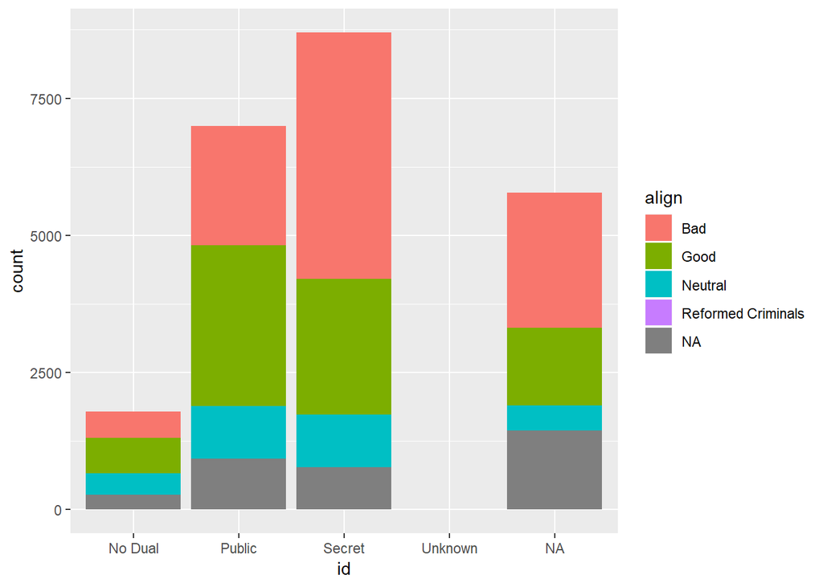

```r
# x-axis id is factor variable, so bar chart fill by another categorical variable align
ggplot(comics, aes(x = id, fill = align)) +
  geom_bar()
```

## 3.1 Contingency table review

comics dataset is collection of characteristics on all the superheroes created by Marvel and DC comics in the last 80 years.

Let’s start by creating a contingency table Which is a useful way to represent the total counts of observations that fall into each combination of the levels of categorical variables.

```r
head(comics,2)
```

```
##                              name     id align        eye       hair
## 1       Spider-Man (Peter Parker) Secret  Good Hazel Eyes Brown Hair
## 2 Captain America (Steven Rogers) Public  Good  Blue Eyes White Hair
##   gender  gsm             alive appearances first_appear publisher
## 1   Male <NA> Living Characters        4043       Aug-62    marvel
## 2   Male <NA> Living Characters        3360       Mar-41    marvel
```

```r
levels(comics$align)
```

```
## [1] "Bad"                "Good"               "Neutral"
## [4] "Reformed Criminals"
```

```r
levels(comics$gender)
```

```
## [1] "Female" "Male"   "Other"
```

```r
table(comics$align, comics$gender)
```

```
##
##                      Female Male Other
##   Bad                  1573 7561    32
##   Good                 2490 4809    17
##   Neutral               836 1799    17
##   Reformed Criminals      1    2     0
```

## 3.2 Dropping levels

The contingency table from the last exercise revealed that there are some levels that have very low counts. To simplify the analysis, it often helps to drop such levels.

In R, this requires two steps: - first filtering out any rows with the levels that have very low counts - then removing these levels from the factor variable with droplevels() - this is because the droplevels() function would keep levels that have even just 1 or 2 counts - it only drops levels that have no count

```r
#Remove 'Reformed Criminals' and also drop that level
comics = comics %>%
  filter(align != 'Reformed Criminals') %>%
  droplevels()

table(comics$align, comics$gender)
```

```
##
##           Female Male Other
##   Bad       1573 7561    32
##   Good      2490 4809    17
##   Neutral    836 1799    17
```

## 3.3 Side-by-side barcharts for two categorical variables

While a contingency table represents the counts numerically it’s often more useful to represent them graphically.

Here you’ll construct two side-by-side barcharts of the comics data. This shows that there can often be two or more options for presenting the same data. Passing the argument position = ‘dodge’ to geom_bar() says that you want a side-by-side (i.e. not stacked) barchart.

side-by-sie indicates separate bar for each category { y axis has the frequency }

Create a side-by-side barchart with align on the x-axis and gender as the fill aesthetic.

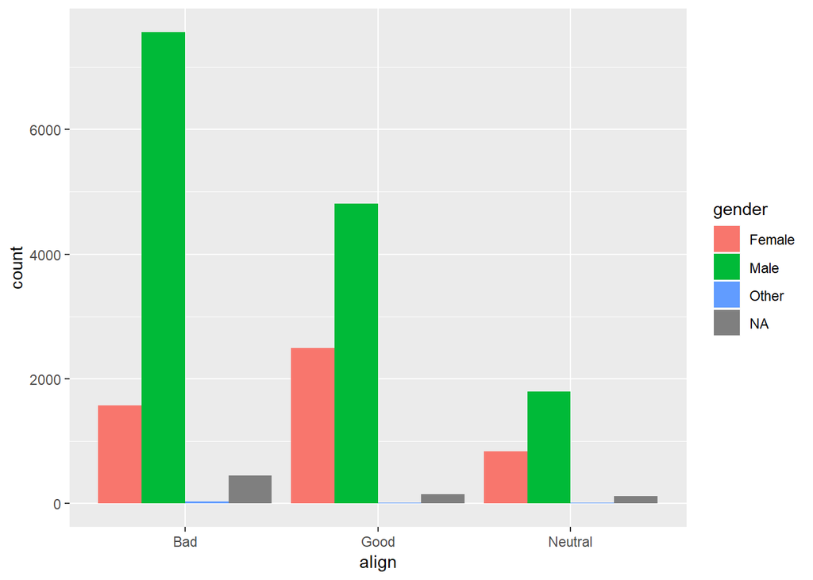

```r
# Side-by-side barchart for male female characters
ggplot(comics, aes(x = align, fill = gender)) +
  geom_bar(position = "dodge")
```

Create another side-by-side barchart with gender on the x-axis and align as the fill aesthetic. Rotate the axis labels 90 degrees to help readability.

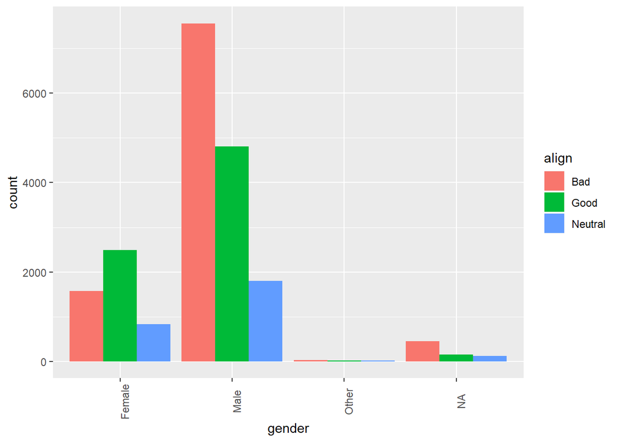

```r
# Side-by-side barchart for gender based characters
ggplot(comics, aes(x = gender, fill = align)) +
  geom_bar(position = "dodge") +
  theme(axis.text.x = element_text(angle = 90))
```

## 3.4 Counts vs. proportions: From counts to proportions

```r
# Simplify display format
options(scipen = 999, digits = 3)
tab_cnt = table(comics$id, comics$align)
tab_cnt
```

```
##
##            Bad Good Neutral
##   No Dual  474  647     390
##   Public  2172 2930     965
##   Secret  4493 2475     959
##   Unknown    7    0       2
```

```r
prop.table(tab_cnt)
```

```
##
##                Bad     Good  Neutral
##   No Dual 0.030553 0.041704 0.025139
##   Public  0.140003 0.188862 0.062202
##   Secret  0.289609 0.159533 0.061815
##   Unknown 0.000451 0.000000 0.000129
```

```r
sum(prop.table(tab_cnt))
```

```
## [1] 1
```

```r
# Conditional proportions : condition on the rows (i.e. rows sum to 1)
prop.table(tab_cnt, 1)
```

```
##
##             Bad  Good Neutral
##   No Dual 0.314 0.428   0.258
##   Public  0.358 0.483   0.159
##   Secret  0.567 0.312   0.121
##   Unknown 0.778 0.000   0.222
```

interpretation: so we can see that 57 % of all secret characters are Bad 31% are good and 12% are neutral

```r
# condition on the columns: i.e. column sum to 1
prop.table(tab_cnt, 2)
```

```
##
##                Bad     Good  Neutral
##   No Dual 0.066331 0.106907 0.168394
##   Public  0.303946 0.484137 0.416667
##   Secret  0.628743 0.408956 0.414076
##   Unknown 0.000980 0.000000 0.000864
```

Now columns sum to 1 and we learned 63 % of Bad characters secret

Proportions in graphs is like scaling instead of side-by-side bars for each category we fill the bar for the category and scale the y-axis frequency/count to proportion 0-1 all bars will be same height as we are comparing proportion of fill for the variable on x axis

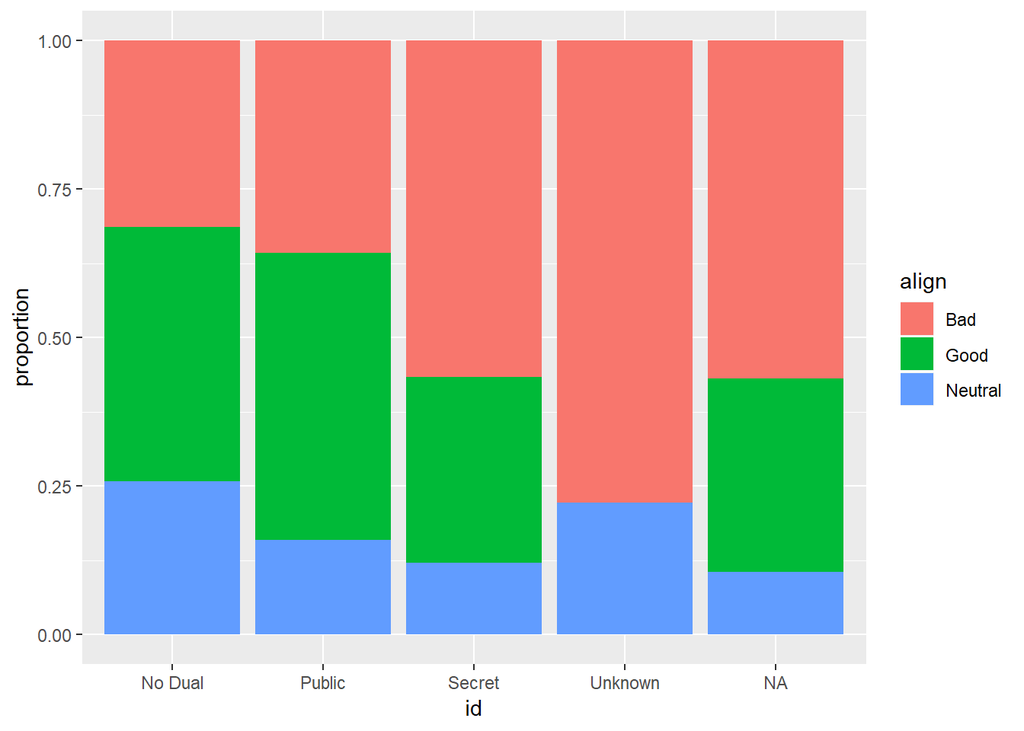

```r
ggplot(comics, aes(x = id, fill = align)) +
  geom_bar(position = "fill") +
  ylab("proportion")
```

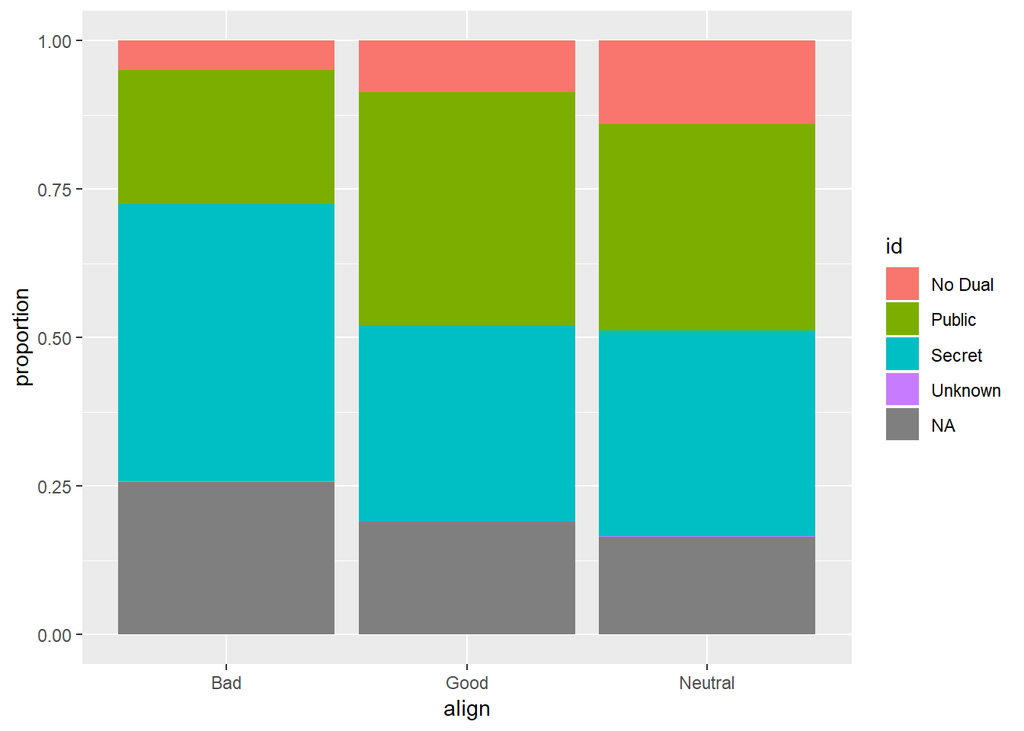

```r
ggplot(comics, aes(x = align, fill = id)) +
  geom_bar(position = "fill") +
  ylab("proportion")
```

```r
# Approximately what proportion of all female characters are good
tab = table(comics$align, comics$gender)
options(scipen = 999, digits = 3) # Print fewer digits

prop.table(tab) #Joint proportions
```

```
##
##             Female     Male    Other
##   Bad     0.082210 0.395160 0.001672
##   Good    0.130135 0.251333 0.000888
##   Neutral 0.043692 0.094021 0.000888
```

```r
# Proportion based on column, that is gender, that is column total should be 1
prop.table(tab,2)
```

```
##
##           Female  Male Other
##   Bad      0.321 0.534 0.485
##   Good     0.508 0.339 0.258
##   Neutral  0.171 0.127 0.258
```

51%

Nice! To answer this question, you needed to look at how align was distributed within each gender. That is, you wanted to condition on the gender variable.

Note: In proportion all bars are same height and fill category corresponds to the proportion

**Counts vs. proportions**

Bars charts can tell dramatically different stories depending on whether they represent counts or proportions and, if proportions, what the proportions are conditioned on.

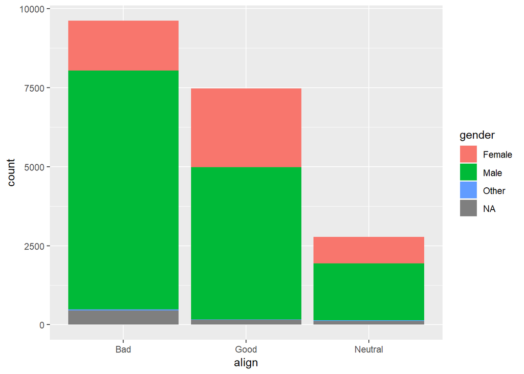

```r
# Create a stacked barchart of gender counts with align on the x-axis
ggplot(comics, aes(x = align, fill = gender)) +
  geom_bar()
```

Create a stacked barchart of gender proportions with alignon the x-axis by setting the position argument to geom_bar() equal to ‘fill’.

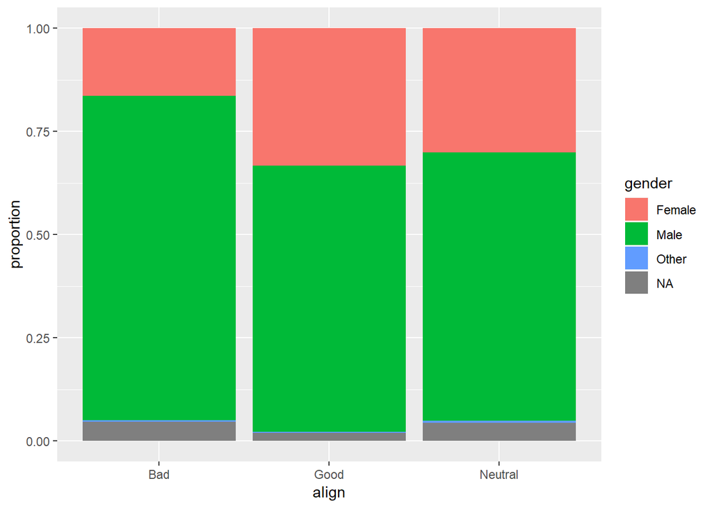

```r
ggplot(comics, aes(x = align, fill = gender)) +
  geom_bar(position = 'fill') +
  ylab("proportion")
```

By adding position = ‘fill’ to geom_bar(), you are saying you want the bars to fill the entire height of the plotting window, thus displaying proportions and not raw counts.

## 3.5 Distribution of one variable : Marginal distribution

```r
table(comics$id)
```

```
##
## No Dual  Public  Secret Unknown
##    1511    6067    7927       9
```

```r
tab_cnt
```

```
##
##            Bad Good Neutral
##   No Dual  474  647     390
##   Public  2172 2930     965
##   Secret  4493 2475     959
##   Unknown    7    0       2
```

This is like summing up the row of single row of contingency table 474 + 647 + 390 = 1511 Since we have summed over the margins of other variables this is sometimes known as marginal distribution

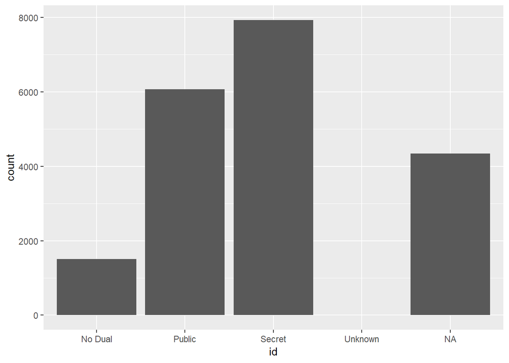

```r
# plot the distribution of id, x-axis factor variable so bar chart
ggplot(comics, aes(x = id)) +
  geom_bar()
```

## 3.6 Distribution of id for all neutral characters**

**We could filter the dataset to include only neutral characters or we could use a technique called faceting Faceting breaks the data into subsets based on a categorical variable and then constructs a plot for each facet_wrap(~align)**

implying broken down by align, that is character

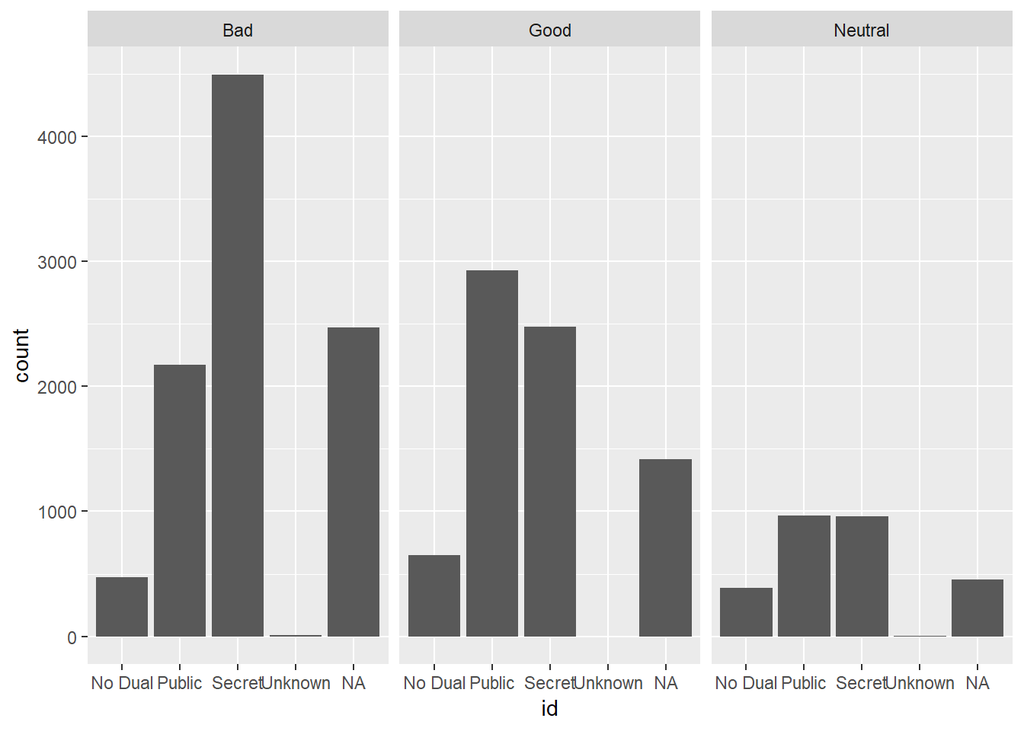

```r
ggplot(comics, aes(x=id)) +
  geom_bar() +
  facet_wrap(~align)
```

The result is three simple barcharts side-by-side - one for each of alignments/characters viz. Bad Good Neutral

## 3.7 Faceting vs. stacking

Facet - one chart for each category stacking - one bar with proportion of the categories

## 3.8 Pie chart vs. bar chart

In pie charts it is not easy to determine the proportional differences if sections sizes don’t differ too much, with bars difference is clear hence barcharts are preferrable.

## 3.9 Marginal barchart

If you are interested in the distribution of alignment of all superheroes, it makes sense to construct a barchart for just that single variable.

You can improve the interpretability of the plot, though, by implementing some sensible ordering. Superheroes that are ‘Neutral’ shown an alignment between Good and Bad so it makes sense to put that bar in the middle.

```r
str(comics$align)
```

```
##  Factor w/ 3 levels "Bad","Good","Neutral": 2 2 3 2 2 2 2 2 3 2 ...
```

```r
# Change the order of the levels in align
comics$align = factor(comics$align, levels = c("Bad", "Neutral", "Good"))

str(comics$align)
```

```
##  Factor w/ 3 levels "Bad","Neutral",..: 3 3 2 3 3 3 3 3 2 3 ...
```

```r
levels(comics$align)
```

```
## [1] "Bad"     "Neutral" "Good"
```

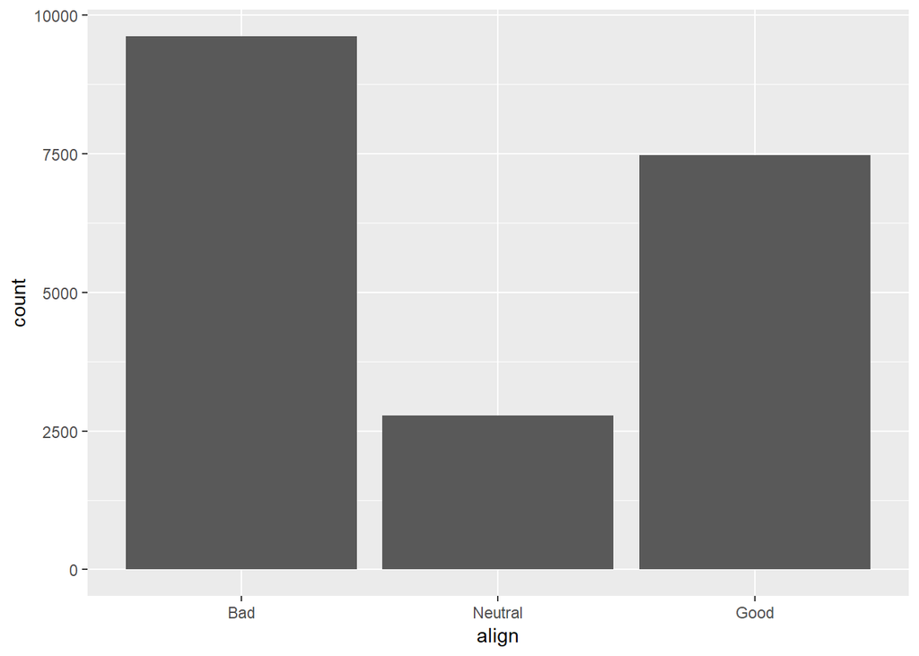

```r
# Create a simple barchart plot of align
ggplot(comics, aes(x = align)) +
  geom_bar()
```

## 3.10 Conditional barchart

Conditional barchart - {based on other categorical variable - faceting}

Now if you want to break down the distribution of alignment based on gender, you’re looking for conditional distribution.

You could make these by creating multiple filtered datasets (on for each gender) or by faceting the plot of alignment based on gender.

**Create a barchart of align faceted by gender**

plot will be broken down into as many categories for gender variable each plot will be a simple barchart for align variable for corresponding gender variable remember to use ~

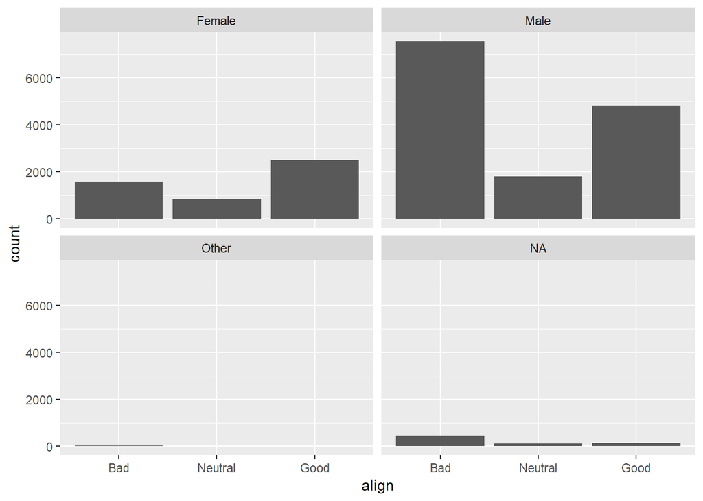

```r
ggplot(comics, aes(x = align)) +
  geom_bar() +
  facet_wrap(~ gender)
```

Improve piechart The piechart is a very common way to represent the distribution of a single categorical variable, but they can be more difficult to interpret than barcharts.

# 4 Exploring numerical dataset cars

Dotplot vs Histogram vs Density plot vs Boxplot

```r
glimpse(cars)
```

```
## Observations: 428
## Variables: 19
## $ name        <fct> Chevrolet Aveo 4dr, Chevrolet Aveo LS 4dr hatch, C...
## $ sports_car  <lgl> FALSE, FALSE, FALSE, FALSE, FALSE, FALSE, FALSE, F...
## $ suv         <lgl> FALSE, FALSE, FALSE, FALSE, FALSE, FALSE, FALSE, F...
## $ wagon       <lgl> FALSE, FALSE, FALSE, FALSE, FALSE, FALSE, FALSE, F...
## $ minivan     <lgl> FALSE, FALSE, FALSE, FALSE, FALSE, FALSE, FALSE, F...
## $ pickup      <lgl> FALSE, FALSE, FALSE, FALSE, FALSE, FALSE, FALSE, F...
## $ all_wheel   <lgl> FALSE, FALSE, FALSE, FALSE, FALSE, FALSE, FALSE, F...
## $ rear_wheel  <lgl> FALSE, FALSE, FALSE, FALSE, FALSE, FALSE, FALSE, F...
## $ msrp        <int> 11690, 12585, 14610, 14810, 16385, 13670, 15040, 1...
## $ dealer_cost <int> 10965, 11802, 13697, 13884, 15357, 12849, 14086, 1...
## $ eng_size    <dbl> 1.6, 1.6, 2.2, 2.2, 2.2, 2.0, 2.0, 2.0, 2.0, 2.0, ...
## $ ncyl        <int> 4, 4, 4, 4, 4, 4, 4, 4, 4, 4, 4, 4, 4, 4, 4, 4, 4,...
## $ horsepwr    <int> 103, 103, 140, 140, 140, 132, 132, 130, 110, 130, ...
## $ city_mpg    <int> 28, 28, 26, 26, 26, 29, 29, 26, 27, 26, 26, 32, 36...
## $ hwy_mpg     <int> 34, 34, 37, 37, 37, 36, 36, 33, 36, 33, 33, 38, 44...
## $ weight      <int> 2370, 2348, 2617, 2676, 2617, 2581, 2626, 2612, 26...
## $ wheel_base  <int> 98, 98, 104, 104, 104, 105, 105, 103, 103, 103, 10...
## $ length      <int> 167, 153, 183, 183, 183, 174, 174, 168, 168, 168, ...
## $ width       <int> 66, 66, 69, 68, 69, 67, 67, 67, 67, 67, 67, 67, 67...
```

## 4.1 Dotplot

Most common way to plot numerical data is dotplot where each case is plotted as a dot on the x-axis

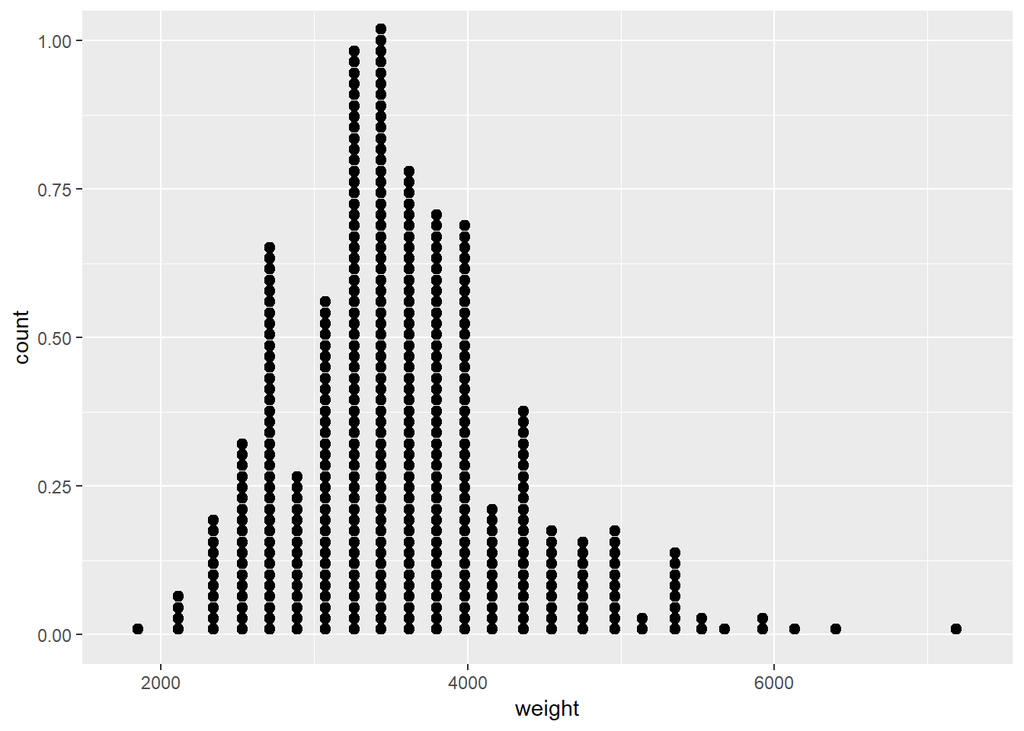

```r
ggplot(cars, aes(x = weight)) +
  geom_dotplot(dotsize = 0.4)
```

## 4.2 Histogram

In Dotplot there is zero information loss and the dataset can be rebuilt from it, but it gets difficult to read dotplots as the number of cases gets very large. To solve this problem use histograms which aggregate the plot into bins on the x-axis and height of the bin corresponding to the number of cases that fall in that bin

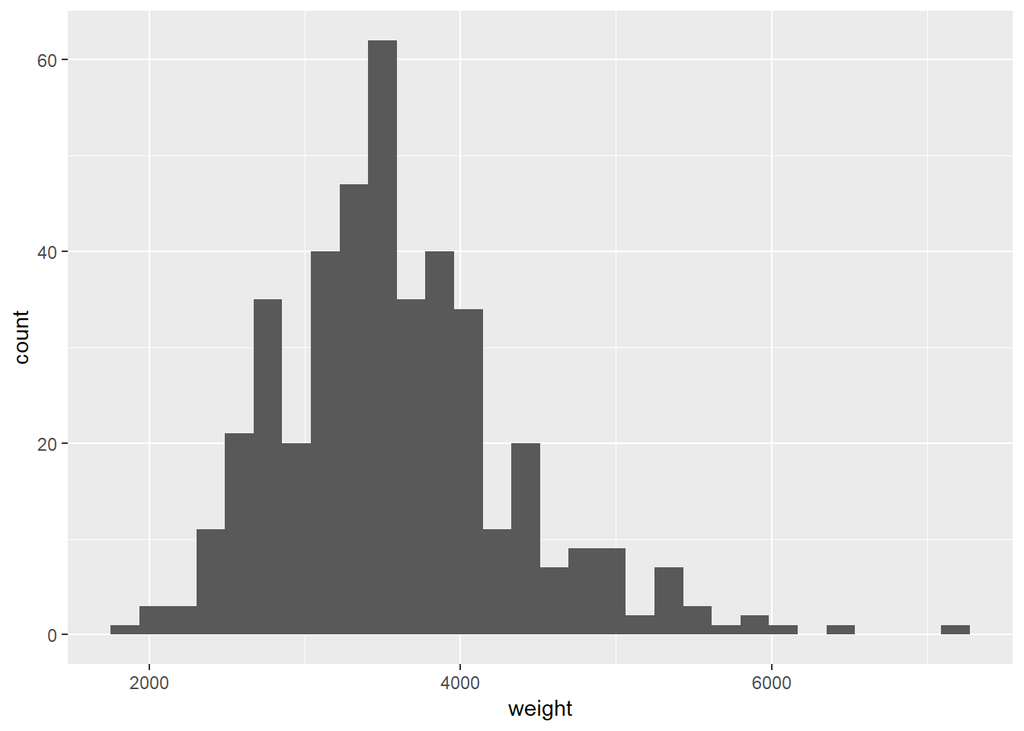

```r
ggplot(cars, aes(x = weight)) +
  geom_histogram()
```

## 4.3 Density Plot

Due to the binning it is not possible to perfectly reconstruct the dataset from histograms but what we gain is the bigger picture of the distribution of the data If the step-wise structure of the histogram irks you then you will like the Density plot.

Density plot represents the shape of the Histogram using a smooth line - this provides an even bigger picture representation of the shape of the distribution

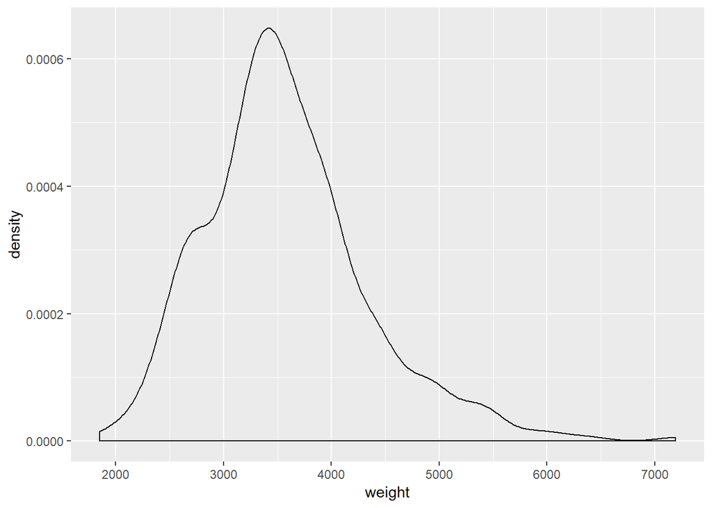

```r
ggplot(cars, aes(x = weight)) +
  geom_density()
```

## 4.4 Boxplot

So you will only want to use density plot when you have a large number of cases.

If you would want a more abstracted sense of distribution then you could identify the center of the distribution the values that markoff the middle half of the data and the values that markoff the vast majority of the data these values can then be used to construct a boxpolt.

Where the box represents the central bulk of the data the whiskers contain almost all of the data and the extreme values are represented as points.

x-axis numerical variable weight, boxplot shows summary stats along y-axis so set x to 1

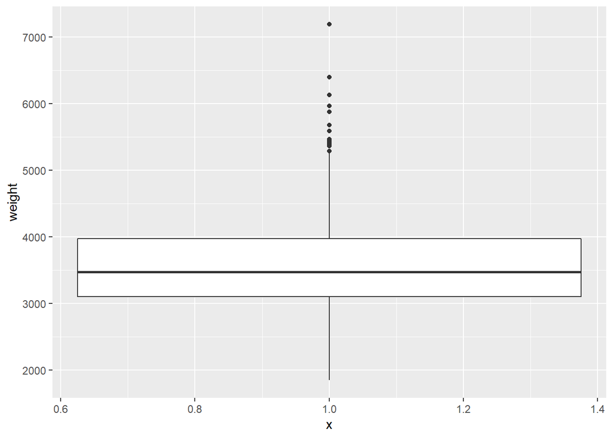

```r
ggplot(cars, aes(x=1, y = weight)) +
  geom_boxplot()
```

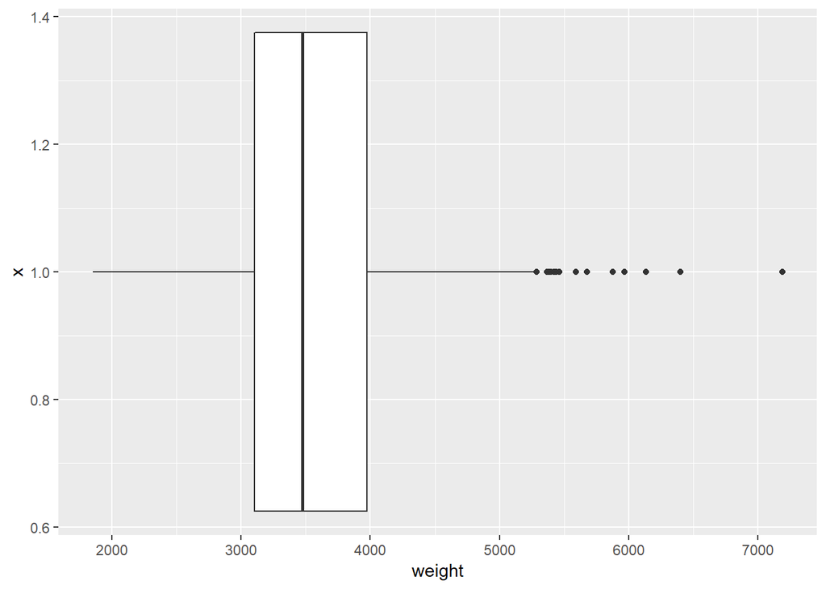

```r
ggplot(cars, aes(x=1, y = weight)) +
  geom_boxplot() +
  coord_flip()
```

```r
str(cars$hwy_mpg)
```

```
##  int [1:428] 34 34 37 37 37 36 36 33 36 33 ...
```

Distribution of highway mileage on the condition of whether or not the car is a pickup truck

```
## Warning: Removed 14 rows containing non-finite values (stat_bin).
```

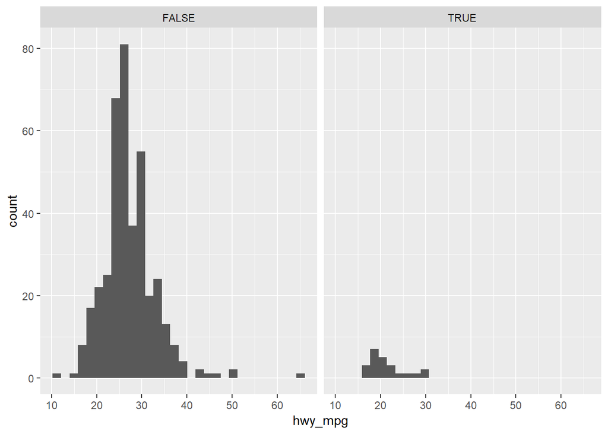

```r
# hwy_mpg is a numerical variable so histogram, faceted by pickup
ggplot(cars, aes(x = hwy_mpg)) +
  geom_histogram() +
  facet_wrap(~pickup)
```

We get a warning that there are 14 missing values.

Faceted histogram plot is informative - it tells us that there are many more non pickups than pick ups - median 26 vs median 20 shows that non-pickup get much better mileage - also non-pickups have more variability than the pickups - keep an eye on the typical observation and the variability of the distribution as you practise exploring numberical data

## 4.5 Faceted histogram

" In this chapter you’ll be working with the cars dataset which records characteristics on all of the new models of cars for sale in the US in a certain year. You will investigate the distribution of mileage across a categorical variable, but before you get there, you’ll want to familiarize yourself with the dataset "

**Plot a histogram of city_mpg faceted by suv**

```r
str(cars$city_mpg)
```

```
##  int [1:428] 28 28 26 26 26 29 29 26 27 26 ...
```

```r
str(cars$suv)
```

```
##  logi [1:428] FALSE FALSE FALSE FALSE FALSE FALSE ...
```

```r
table(cars$suv)
```

```
##
## FALSE  TRUE
##   368    60
```

x-axis numerical variable city_mpg so histogram, faceted by logical variable suv

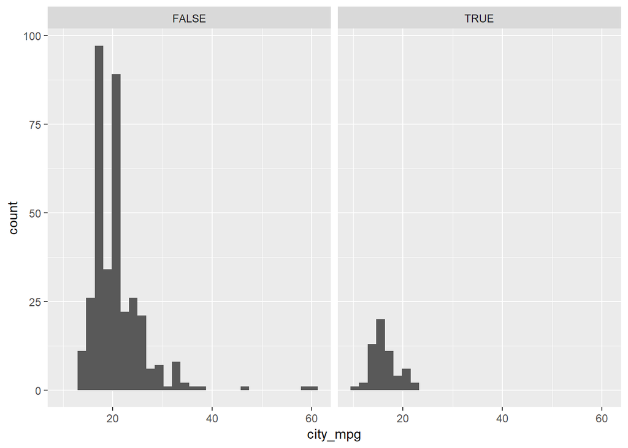

```r
ggplot(cars, aes(x = city_mpg)) +
  geom_histogram() +
  facet_wrap(~suv)
```

To explore the relationship between these two variables: The mileage of a car tends to be associated with the size of its engine(as measured by the number of cylinders.

```r
names(cars)
```

```
##  [1] "name"        "sports_car"  "suv"         "wagon"       "minivan"
##  [6] "pickup"      "all_wheel"   "rear_wheel"  "msrp"        "dealer_cost"
## [11] "eng_size"    "ncyl"        "horsepwr"    "city_mpg"    "hwy_mpg"
## [16] "weight"      "wheel_base"  "length"      "width"
```

```r
str(cars$hwy_mpg)
```

```
##  int [1:428] 34 34 37 37 37 36 36 33 36 33 ...
```

```r
str(cars$ncyl)
```

```
##  int [1:428] 4 4 4 4 4 4 4 4 4 4 ...
```

```r
length(unique(cars$ncyl))
```

```
## [1] 8
```

```r
table(cars$ncyl)
```

```
##
##  -1   3   4   5   6   8  10  12
##   2   1 136   7 190  87   2   3
```

Filter cars to include only cars with 4, 6, or 8 cylinders and save the result as common_cyl. The %in% operator may prove useful here.

```r
common_cyl = cars %>% filter(ncyl %in% c(4,6,8))
glimpse(common_cyl)
```

```
## Observations: 413
## Variables: 19
## $ name        <fct> Chevrolet Aveo 4dr, Chevrolet Aveo LS 4dr hatch, C...
## $ sports_car  <lgl> FALSE, FALSE, FALSE, FALSE, FALSE, FALSE, FALSE, F...
## $ suv         <lgl> FALSE, FALSE, FALSE, FALSE, FALSE, FALSE, FALSE, F...
## $ wagon       <lgl> FALSE, FALSE, FALSE, FALSE, FALSE, FALSE, FALSE, F...
## $ minivan     <lgl> FALSE, FALSE, FALSE, FALSE, FALSE, FALSE, FALSE, F...
## $ pickup      <lgl> FALSE, FALSE, FALSE, FALSE, FALSE, FALSE, FALSE, F...
## $ all_wheel   <lgl> FALSE, FALSE, FALSE, FALSE, FALSE, FALSE, FALSE, F...
## $ rear_wheel  <lgl> FALSE, FALSE, FALSE, FALSE, FALSE, FALSE, FALSE, F...
## $ msrp        <int> 11690, 12585, 14610, 14810, 16385, 13670, 15040, 1...
## $ dealer_cost <int> 10965, 11802, 13697, 13884, 15357, 12849, 14086, 1...
## $ eng_size    <dbl> 1.6, 1.6, 2.2, 2.2, 2.2, 2.0, 2.0, 2.0, 2.0, 2.0, ...
## $ ncyl        <int> 4, 4, 4, 4, 4, 4, 4, 4, 4, 4, 4, 4, 4, 4, 4, 4, 4,...
## $ horsepwr    <int> 103, 103, 140, 140, 140, 132, 132, 130, 110, 130, ...
## $ city_mpg    <int> 28, 28, 26, 26, 26, 29, 29, 26, 27, 26, 26, 32, 36...
## $ hwy_mpg     <int> 34, 34, 37, 37, 37, 36, 36, 33, 36, 33, 33, 38, 44...
## $ weight      <int> 2370, 2348, 2617, 2676, 2617, 2581, 2626, 2612, 26...
## $ wheel_base  <int> 98, 98, 104, 104, 104, 105, 105, 103, 103, 103, 10...
## $ length      <int> 167, 153, 183, 183, 183, 174, 174, 168, 168, 168, ...
## $ width       <int> 66, 66, 69, 68, 69, 67, 67, 67, 67, 67, 67, 67, 67...
```

```r
common_cyl$ncyl = as.factor(common_cyl$ncyl)
table(common_cyl$ncyl)
```

```
##
##   4   6   8
## 136 190  87
```

**Distribution of city mileage wrt ncyl**

city mileage is numerical variable and ncyl categorical

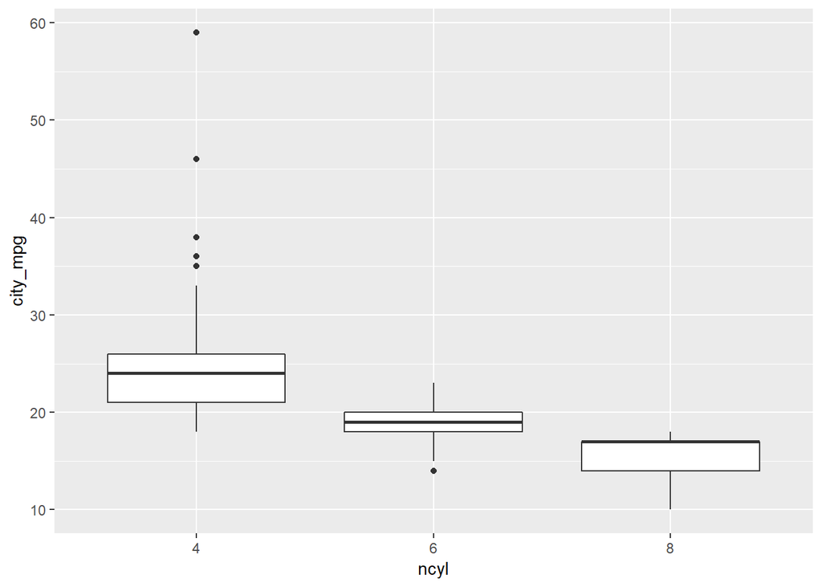

```r
# side-by-side boxplot of city_mpg fro each of the ncyl types
ggplot(common_cyl, aes(x = ncyl, y = city_mpg)) +
  geom_boxplot()
```

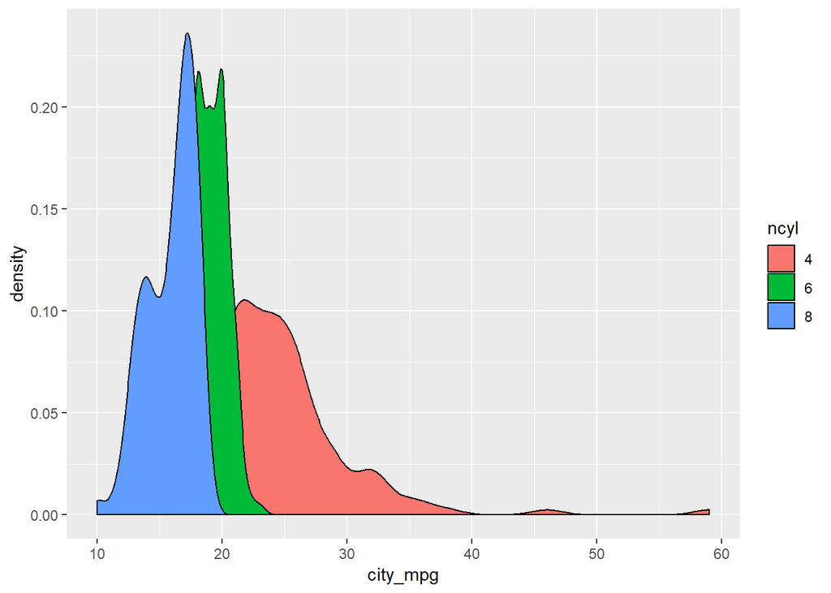

```r
# overlaid density plot of city_mpg coloured by ncyl
ggplot(common_cyl, aes(x = city_mpg, fill = ncyl )) +
  geom_density()
```

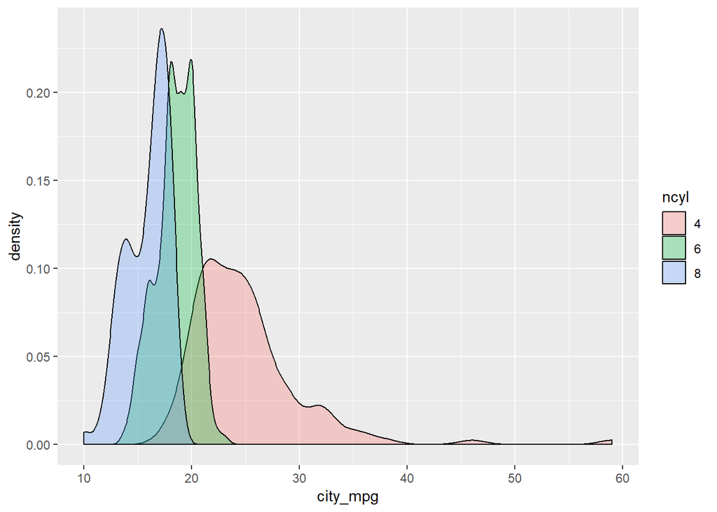

```r
# alpha for trasparency
ggplot(common_cyl, aes(x = city_mpg, fill = ncyl )) +
  geom_density(alpha = 0.3)
```

Which of the following interpretations of the plot is NOT valid?

Possible Answers The highest mileage cars have 4 cylinders.

The typical 4 cylinder car gets better mileage than the typical 6 cylinder car, which gets better mileage than the typical 8 cylinder car.

Most of the 4 cylinder cars get better mileage than even the most efficient 8 cylinder cars.

The variability in mileage of 8 cylinder cars is similar to the variability in mileage of 4 cylinder cars. (ans)

Answer: The city_mpg spread of 4 cyl cars is wider in the density plot - thus the conclusion that variability in mileage of 8 cylinder cars seems much smaller than that of 4 cylinder cars is correct answer.

## 4.6 Distribution of one variable

If you are interested in the distribution of single numerical variable - there are three ways you can get there - first is to look at the marginal distribution - like simple distribution of highway mileage using histogram

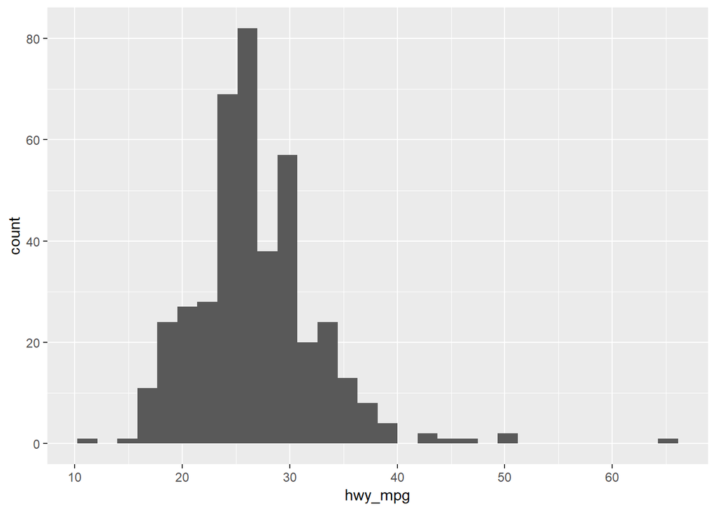

```r
ggplot(cars, aes(x = hwy_mpg)) +
  geom_histogram()
```

If we want to see the distribution on a different subset of the data, says cars that are pickup trucks - we can add the facet_wrap layer to break the distribution for pickups and non-pickups

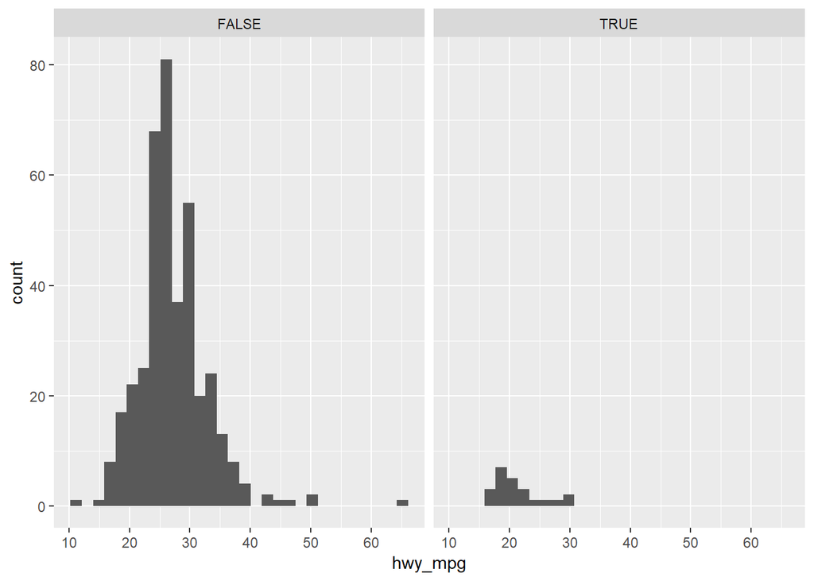

```r
ggplot(cars, aes(x = hwy_mpg)) +
  geom_histogram() +
  facet_wrap(~pickup)
```

Another scenario would be to see the distribution on a subset of the data - says cars that have engine size with less than 2 litres - since engine size is numerical, it won’t work with facets - instead we have to filter out the rows first

```r
str(cars$eng_size)
```

```
##  num [1:428] 1.6 1.6 2.2 2.2 2.2 2 2 2 2 2 ...
```

engine size is numerical and can not be factorised. So we will filter out the rows we need to see the hwy_distribution

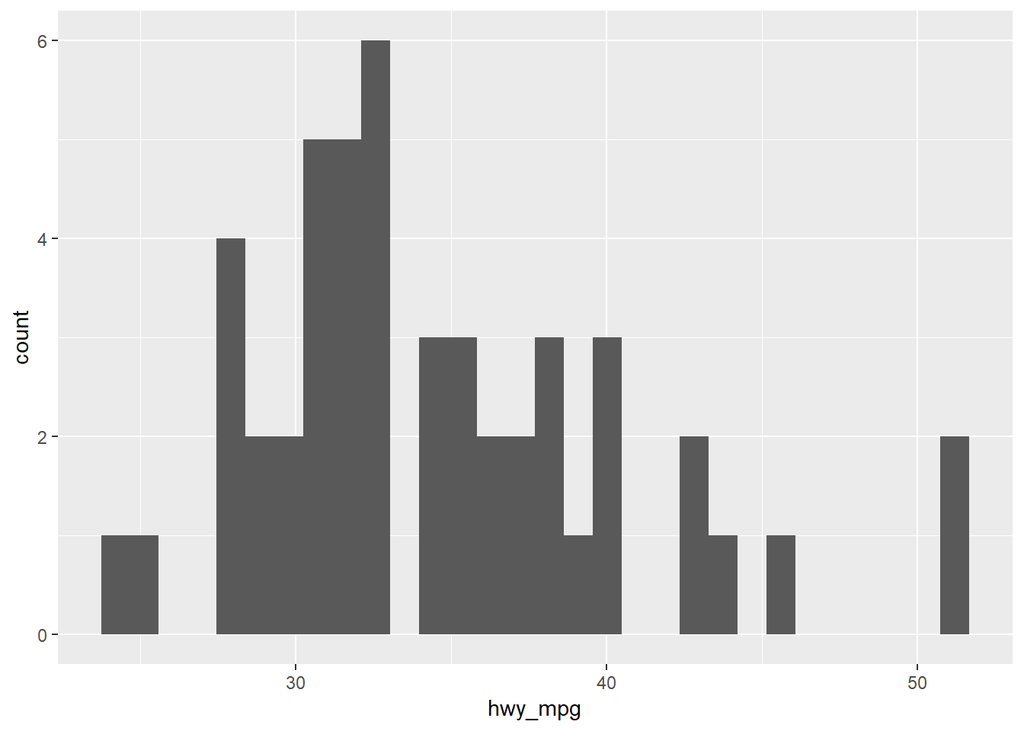

```r
cars2 = cars %>%
  filter(eng_size < 2.0)

ggplot(cars2, aes(x = hwy_mpg)) +
  geom_histogram()
```

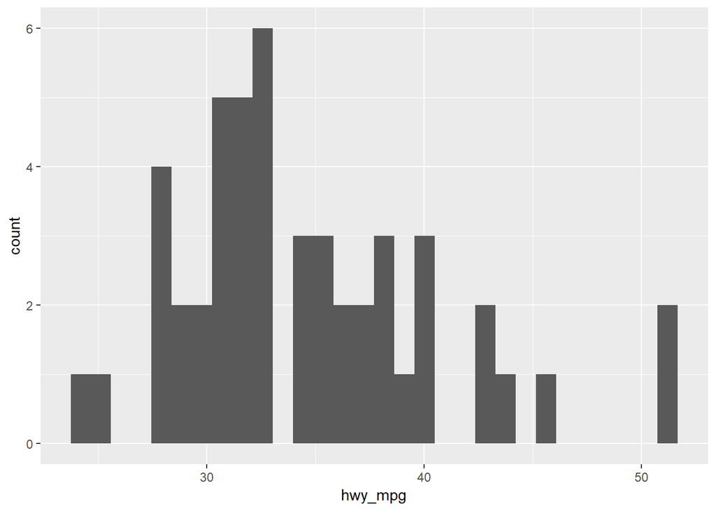

```r
#Using data pipeline for filtering and plotting

cars %>%
  filter(eng_size < 2.0) %>%
  ggplot(aes(x = hwy_mpg)) +
  geom_histogram()
```

Resulting plot makes some sense - these are small cars though - and small engines are usually more efficient - therefore we’re seeing higher mileages than we saw with the whole dataset - your sense of distribution can also change with the binwidth that is selected - ggplot does it’s best to select the binwidth - for wide bin width, use bindwidth argument, set to 5 - the result is a histogram that is much smoother - the same principle holds true for density plots - to plot a smoother density plot use argument bw = 5

How do we decide what is the best bandwidth for a plot - usually the defaults are sensible - but it is good practise to take a look at smoother and less smoother versions of the plots to focus on the different structures of the data

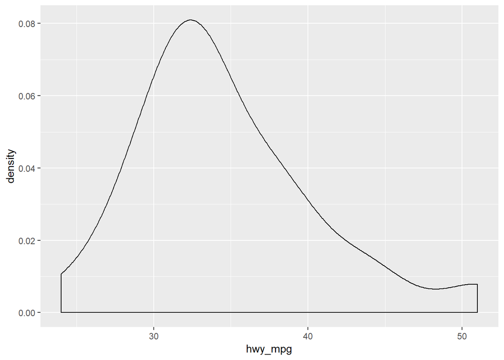

```r
# Density plot
cars %>%
  filter(eng_size < 2.0) %>%
  ggplot(aes(x = hwy_mpg)) +
  geom_density()
```

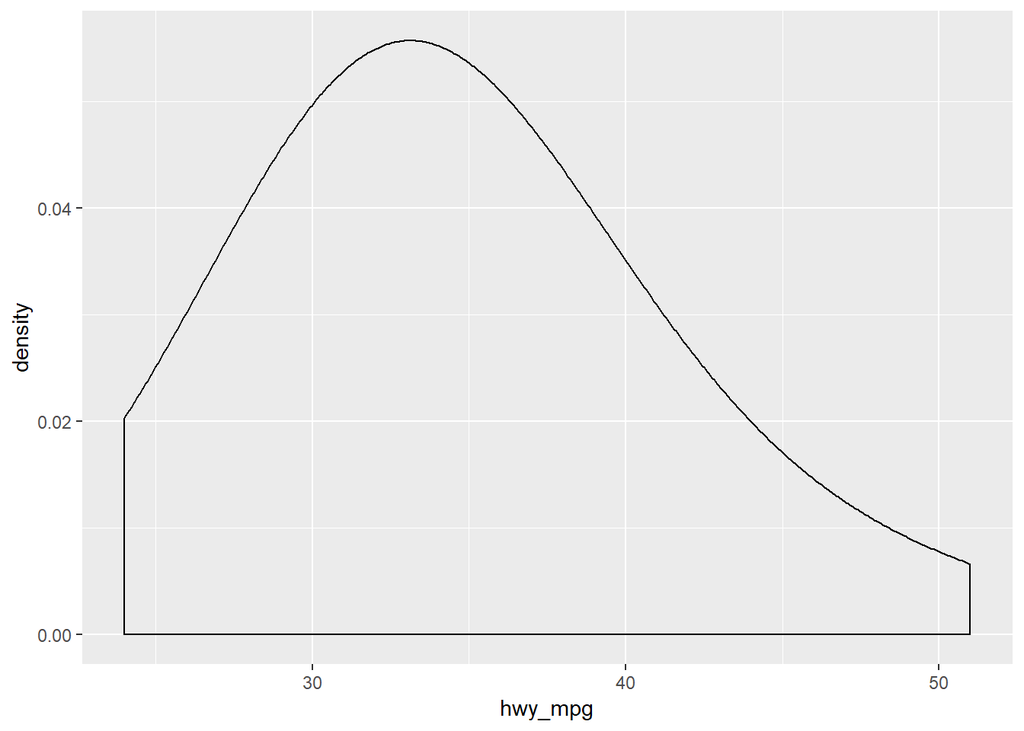

```r
cars %>%
  filter(eng_size < 2.0) %>%
  ggplot(aes(x = hwy_mpg)) +
  geom_density(bw = 5)
```

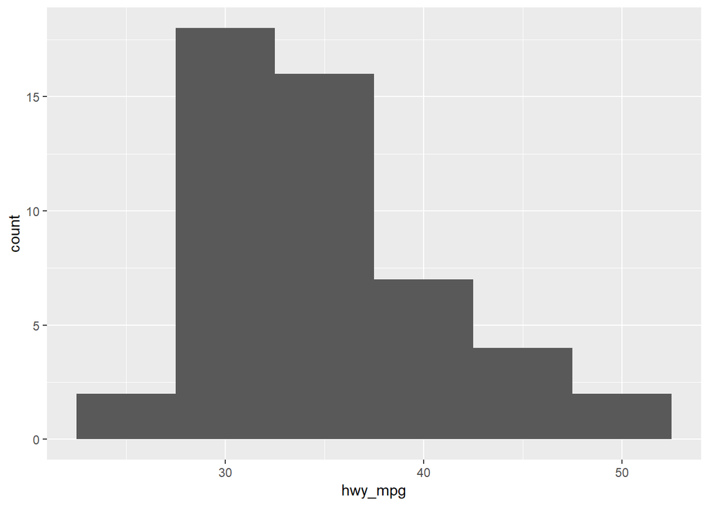

```r
# Wide bin width
cars %>%
  filter(eng_size < 2.0) %>%
  ggplot(aes(x = hwy_mpg)) +
  geom_histogram(binwidth = 5)
```

Marginal and conditional histograms - {marginal is for one variable conditional means subsetted dataset}

Now, turn you attention to a new variable: horsepwr. The goal is to get a sense of the marginal distribution of this variable and then compare it to the distribution of horsepower conditional on the price of the car being less than $25,000

You’ll be making two plots using the ‘data pipeline’ paradigm where you start with the raw data and end with the plot.

## 4.7 Marginal Histogram

Create a histogram of the distribution of horsepwr across all cars and add an appropriate title. Start by piping in the raw dataset.

```r
str(cars$horsepwr)
```

```
##  int [1:428] 103 103 140 140 140 132 132 130 110 130 ...
```

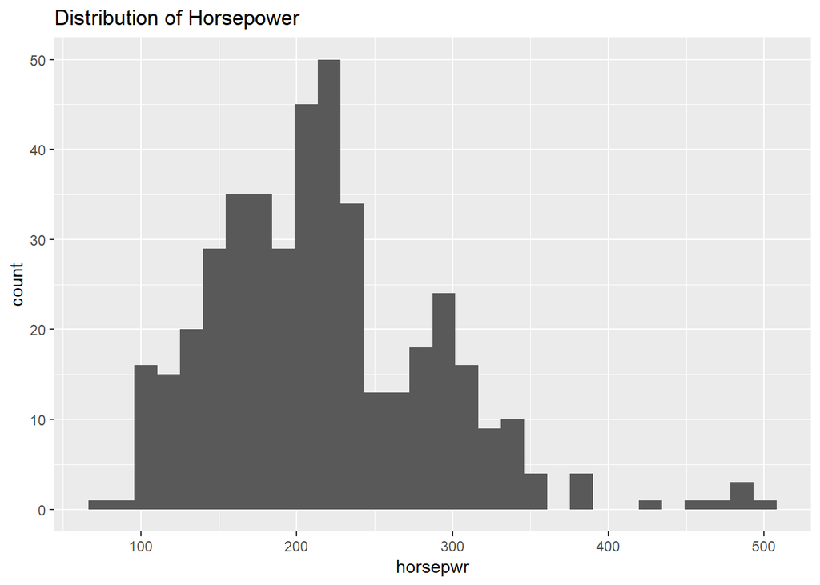

```r
# Distribution of numerical variable horsepwr
cars %>%
  ggplot(aes(x = horsepwr)) +
  geom_histogram() +
  ggtitle("Distribution of Horsepower")
```

## 4.8 Conditional Histogram

Create a second histogram of the distribution of horsepwer, but only for those cars that have an msrp less than $25000 Keep the limits of the x-axis so that they’re similar to that of the first plot, and a descriptive title.

```r
str(cars$msrp)
```

```
##  int [1:428] 11690 12585 14610 14810 16385 13670 15040 13270 13730 15460 ...
```

```r
summary(cars$msrp)
```

```
##    Min. 1st Qu.  Median    Mean 3rd Qu.    Max.
##   10280   20334   27635   32775   39205  192465
```

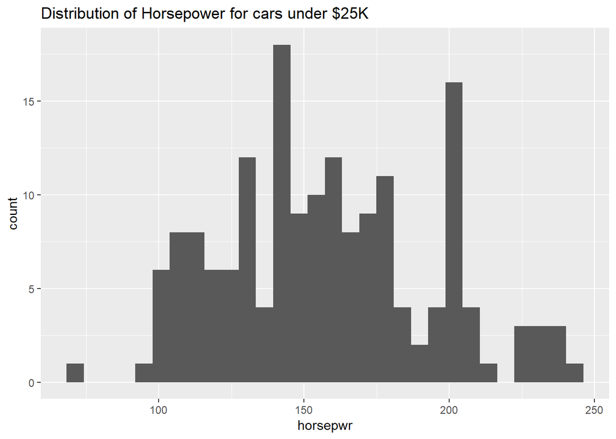

```r
cars %>%
  filter(msrp < 25000) %>%
  ggplot(aes(x = horsepwr)) +
  geom_histogram() +
  ggtitle("Distribution of Horsepower for cars under $25K")
```

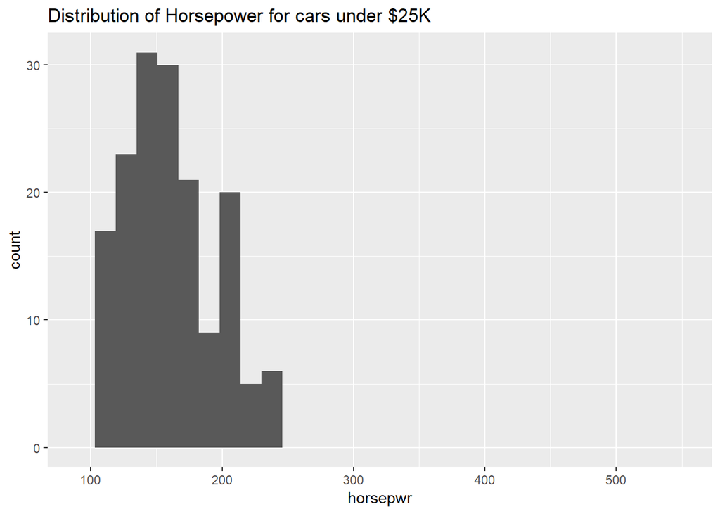

```r
cars %>%
  filter(msrp < 25000) %>%
  ggplot(aes(x = horsepwr)) +
  geom_histogram() +
  xlim(c(90,550)) +
  ggtitle("Distribution of Horsepower for cars under $25K")
```

Marginal and conditional histograms interpretation Observe the two histograms in the plotting window and decide which of the following is a valid interpretation.

Possible Answers Cars with around 300 horsepower are more common than cars with around 200 horsepower.

The highest horsepower car in the less expensive range has just under 250 horsepower. (ans)

Most cars under $25,000 vary from roughly 100 horsepower to roughly 350 horsepower.

Three binwidths Before you take these plots for granted, it’s a good idea to see how things change when you alter the binwidth - The binwidth determines how smooth your distribution will appear - the smaller the binwidth the more jagged your distribution becomes. - it’s good practice to consider several binwidths in order to detect differnt types of structure in your data

Create the following three plots adding a title to each to indicate the binwidth used:

- A histogram of horsepower with a binwidth of 3
- A second histogram of horsepower with a binwidth of 30
- A third histogram of horsepower with a binwidth of 60

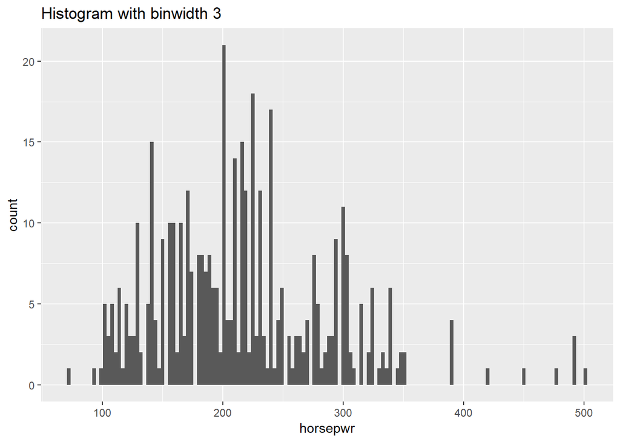

```r
# Create hist of horsepwr with binwidth of 3
cars %>%
  ggplot(aes(x= horsepwr)) +
  geom_histogram(binwidth = 3) +
  ggtitle("Histogram with binwidth 3")
```

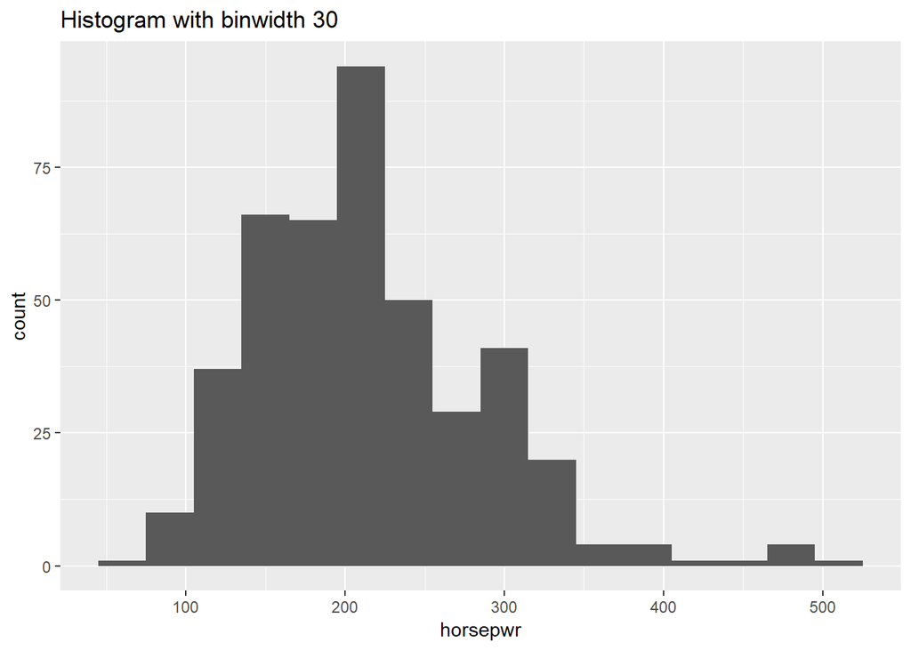

```r
# Create hist of horsepwr with binwidth of 30
cars %>%
  ggplot(aes(horsepwr)) +
  geom_histogram(binwidth = 30) +
  ggtitle("Histogram with binwidth 30")
```

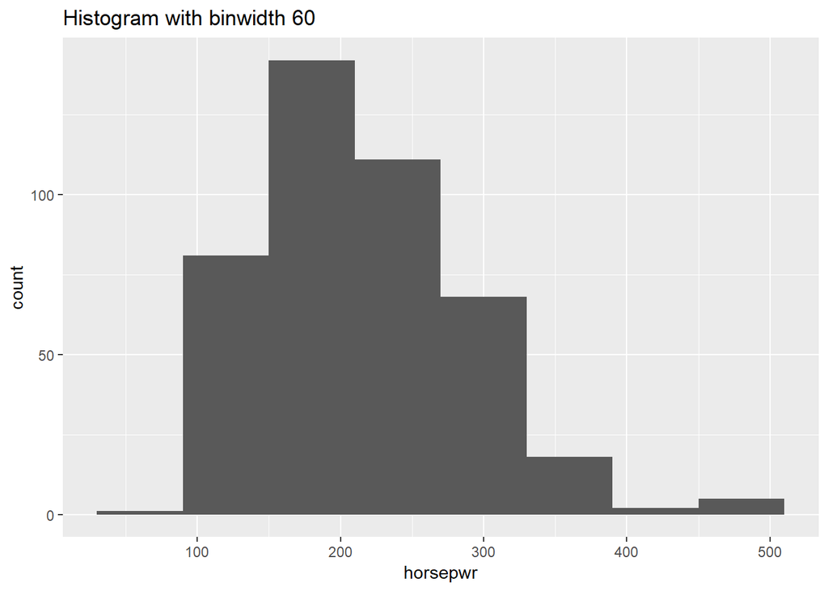

```r
# Create hist of horsepwr with binwidth of 60
cars %>%
  ggplot(aes(horsepwr)) +
  geom_histogram(binwidth = 60) +
  ggtitle("Histogram with binwidth 60")
```

Nice! Be sure to toggle back and forth in the plots pane to compare the histograms.

Three binwidths interpretation What feature is present in Plot A that’s not found in B or C?

Possible Answers The most common horsepower is around 200.

There is a tendency for cars to have horsepower right at 200 or 300 horsepower. (ans)

There is a second mode around 300 horsepowe ()

Nice one! Plot A is the only histogram that shows the count for cars with exactly 200 and 300 horsepower.

## 4.9 Box plots

- how are boxplots constructed starting by dotplots
- boxplots are based around three summary statistics
- first, second and third quartile of the data
- second quartile is the median
- the value that is in the middle of the dataset
- half the data is below it
- and half is above it
- first quartile has quarter of data below it and third quartile has three quarters of data below it
- these three numbers form the box in the box plot
- with the median in the middle and the first & second quartile as the edges
- one thing you’ll notice is that the middle half of the data is inside this box
- there are various rules about where to draw the whiskers that is the line that extends out of the box
- ggplot2 draws it out one and half times the length of box then draws it in to the first observation that is encounter
- the particular rule is less important than the interpretation
- which is the whiskers to encompass nearly all of the data
- any data that is not encompassed by the box or the whiskers is represented as a point
- this is one of the handy features of the boxplot that flag the points that are far away from the bulk of the data
- a form of automated outlier detection
- let’s revisit this side-by-side box plot that you constructed in your exercise

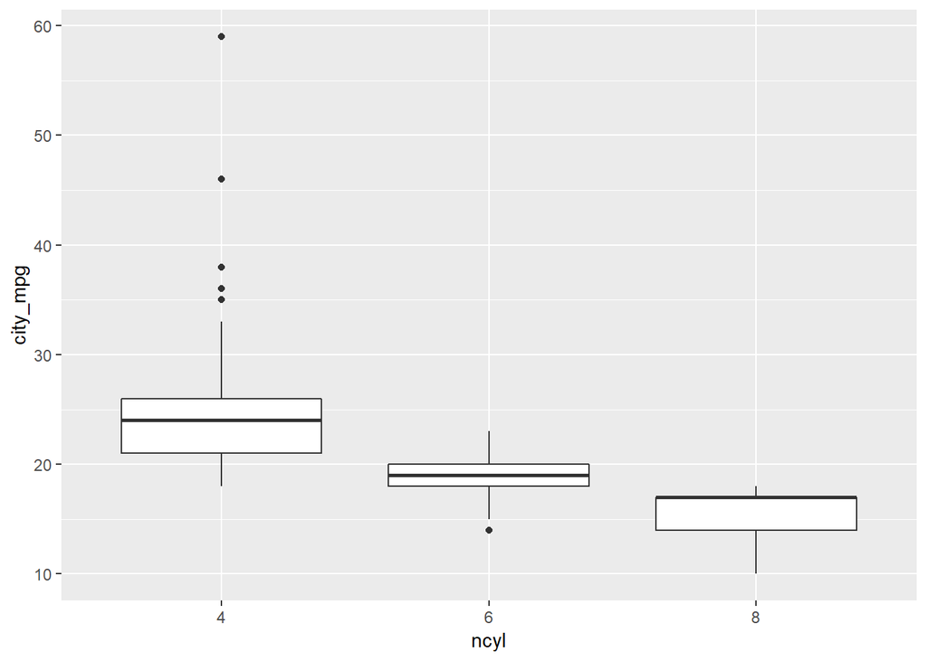

```r
ggplot(common_cyl, aes(x = ncyl, y = city_mpg)) +
  geom_boxplot()
```

The above boxplot shows the distribution of city mileage broken down by cars that have 4 cylinders 6 cylinders and 8 cylinders - the median mileage is greatest for 4 cylinders than for 6 cylinders - for 8 cylinders something odd is going on, the median is very close to the third quartile - in terms of variability 4 cylinder cars have the widest box the whiskers that extend the farthest - the middle half of the data in 6 cylinder cars expands a very small range of values shown by the narrow box - finally we see some outliers, one 6 cylinder car with low mileage and several 4 cylinder cars with high mileage - if you are wondering about that highest outlier in the 4 cylinders category that’s indeed a hybrid vehicle - by syntax ggplot expects you to plot several boxplots side-by-side - if you want to see just a single one, you can set the x argument to 1 ggplot(cars, aes(x=1, y = msrp)) + geom_boxplot() - so boxplots outshine when you have to detect outliers but they cannot detect if there are two humps or modes - if a density plot show two humps for the distribution {that is two bell shape curves or two peaks} and we if we construct a boxplot for the same structure it will push this important structure under the rug and just show a single box

Box plots for outliers In addition to indicating the center and spread of a distribution, a box plot provides a graphical means to detect outliers. You can apply this method to msrp column ( manufacturer’s suggested retail price) to detect if there are unusually expensive or cheap cars.

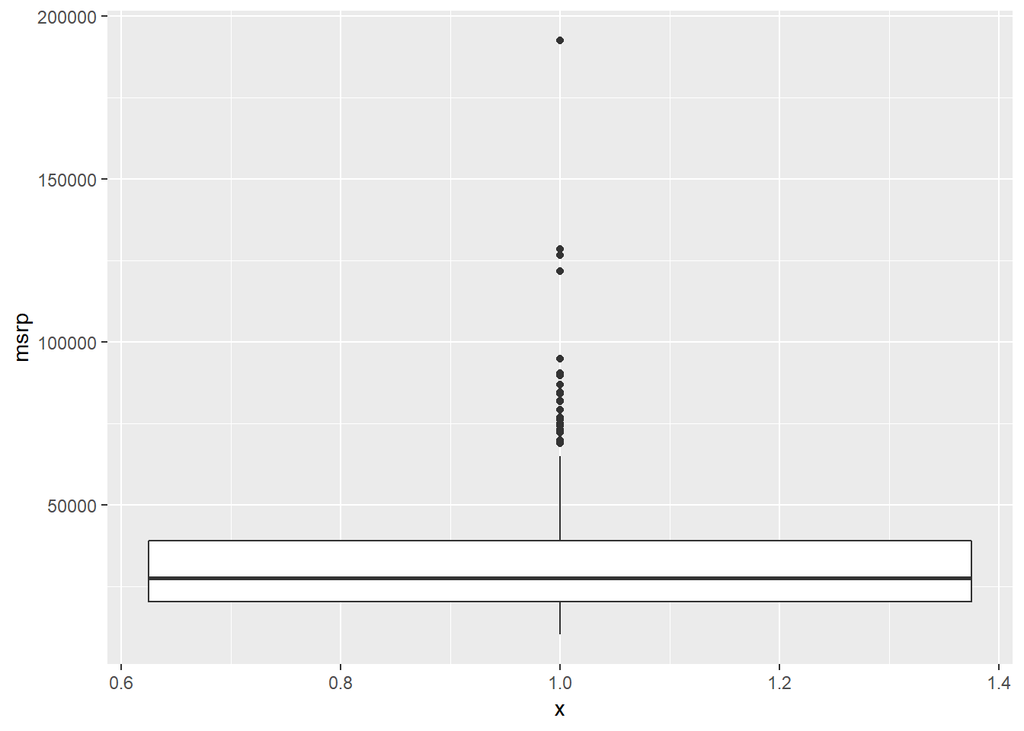

```r
#Construct a box plot of msrp.
cars %>% ggplot(aes(x = 1, y = msrp)) +
geom_boxplot()
```

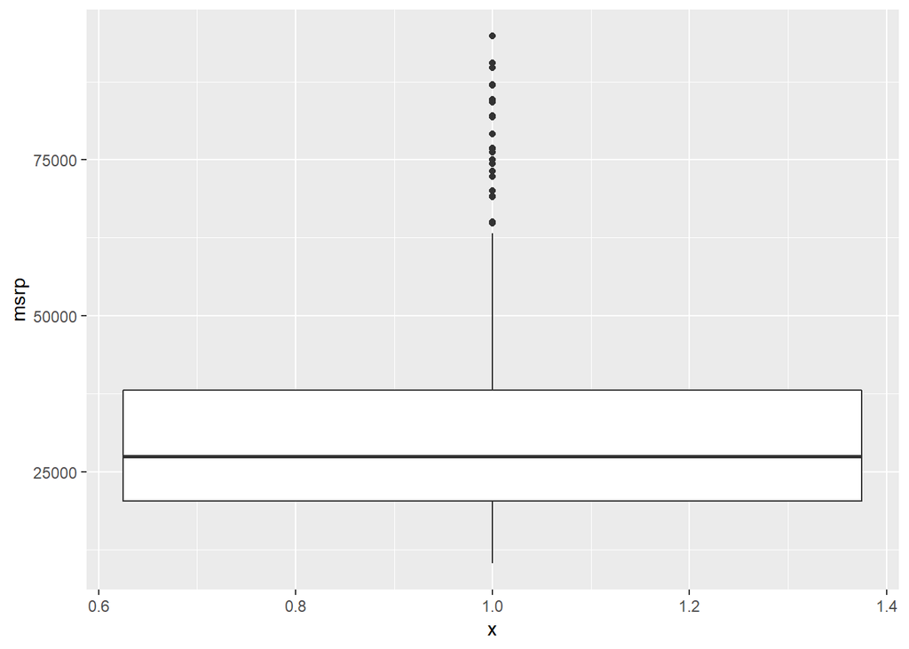

```r
#Exclude the largest 3-5 outliers by filtering the rows to retain
#cars less than $100,000. Save this reduced dataset as cars_no_out.

# Exclude outliers from data
cars_no_out <- cars %>%
filter(msrp < 100000)


#Construct a similar box plot of msrp using this reduced dataset.
#Compare the two plots.

# Construct box plot of msrp using the reduced dataset
cars_no_out %>%
ggplot(aes(x=1, y = msrp)) +
geom_boxplot()
```

# 5 Plot selection

Consider two other columns in the cars dataset: city_mpg and width Which is the most appropriate plot for displaying the important features of their distributions? Remember, both density plots and boxplots display the central tendency and spread of the data, but the box plot is more robust to outliers.

Use density plots or box plots to construct the following visualizations. For each variable, try both plots and submit the one that is better at capturing the important structure.

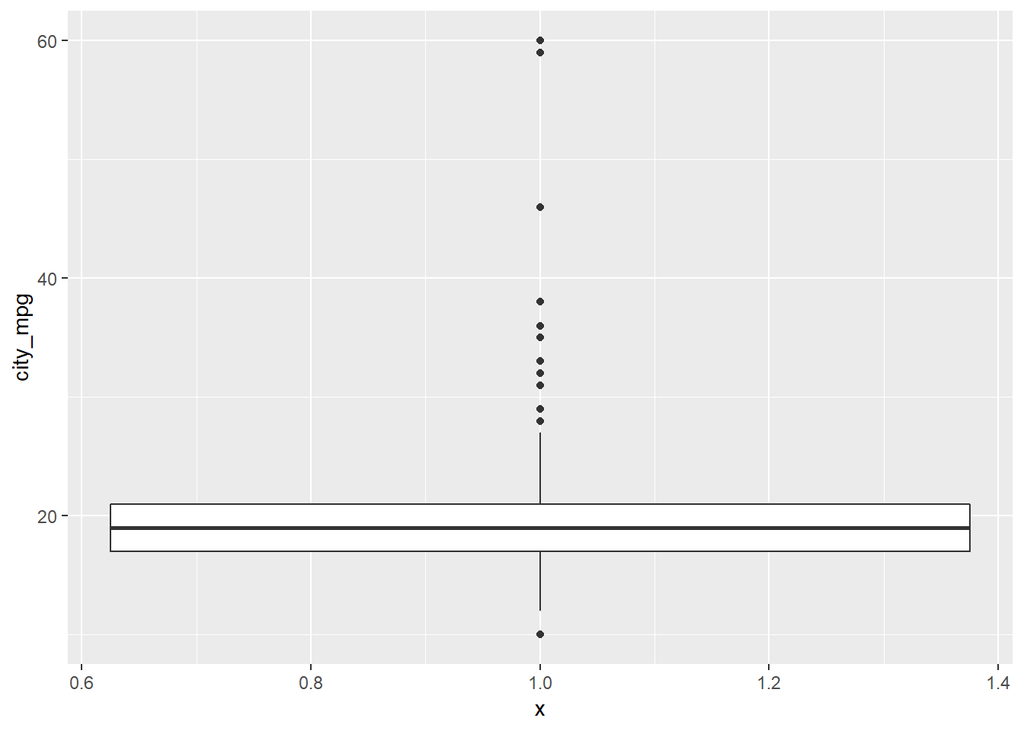

```r
cars %>% ggplot(aes(x = 1, y = city_mpg)) +
  geom_boxplot()
```

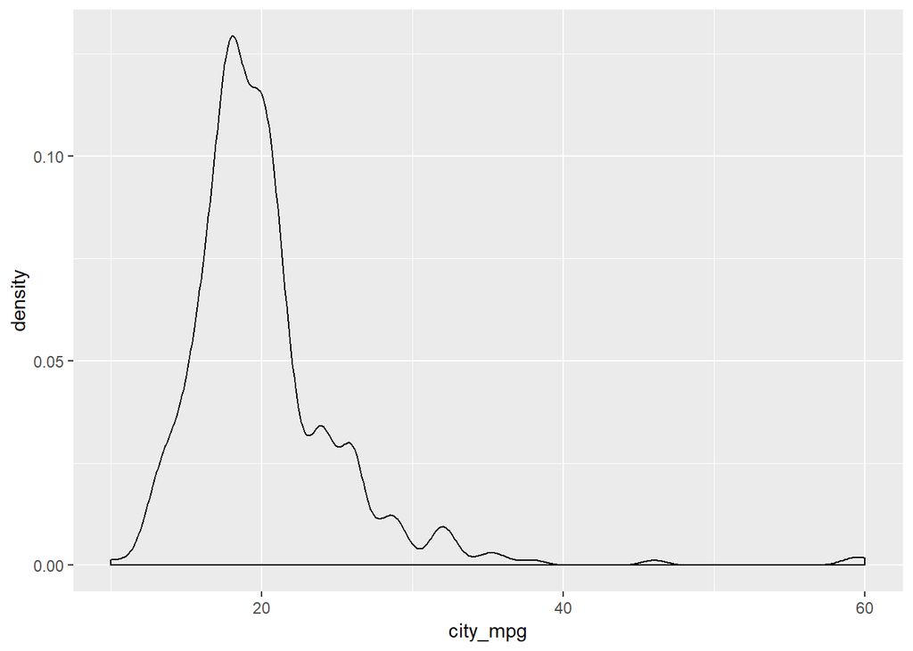

```r
cars %>% ggplot(aes(x = city_mpg)) +
  geom_density()
```

```r
str(cars$width)
```

```
##  int [1:428] 66 66 69 68 69 67 67 67 67 67 ...
```

```r
summary(cars$width)
```

```
##    Min. 1st Qu.  Median    Mean 3rd Qu.    Max.    NA's
##    64.0    69.0    71.0    71.3    73.0    81.0      28
```

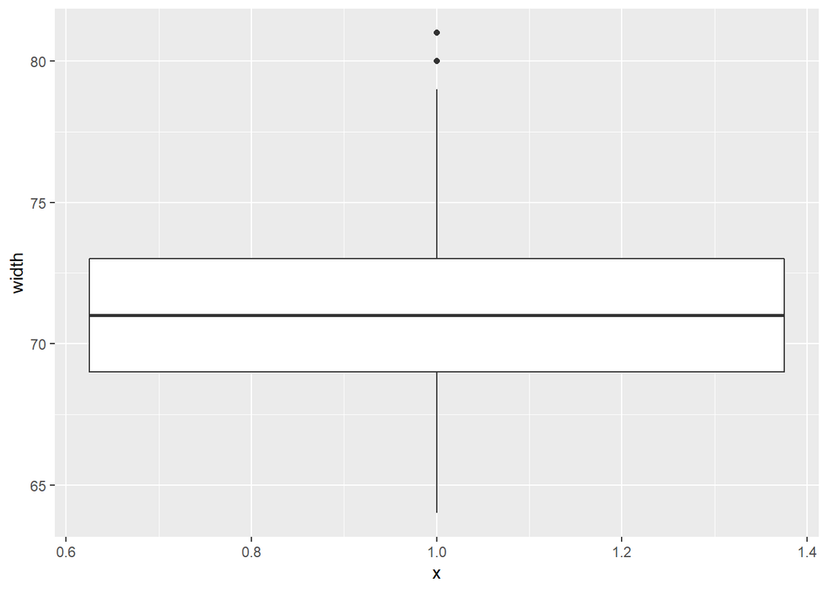

```r
cars %>% ggplot(aes(x = 1, y = width)) +
  geom_boxplot()
```

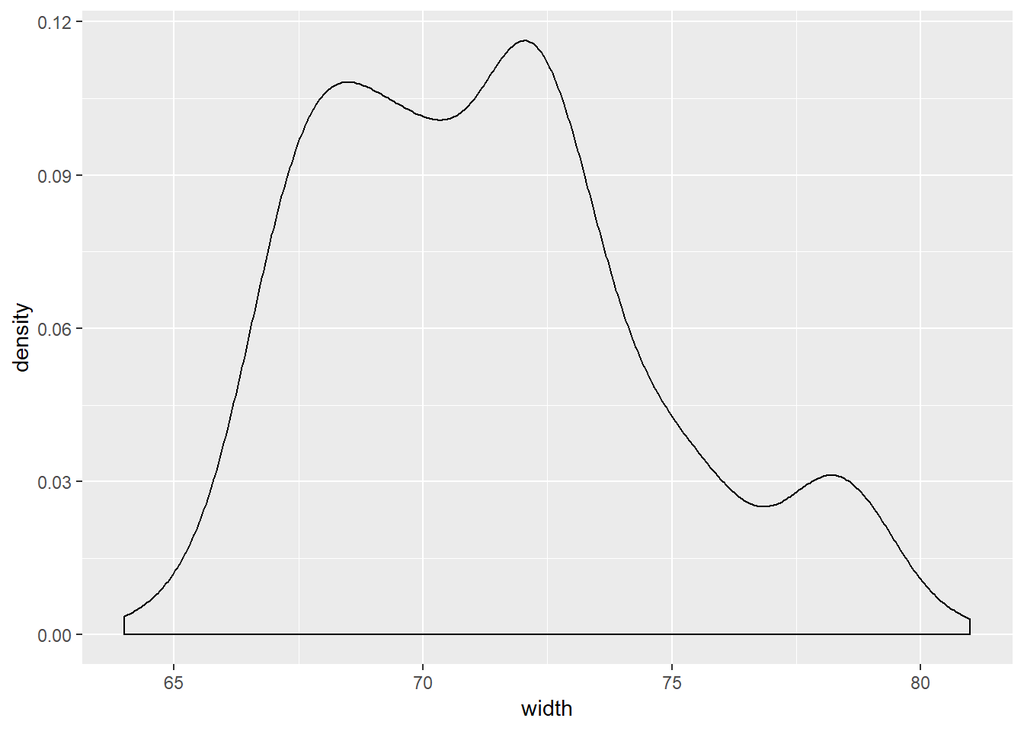

```r
cars %>% ggplot(aes(x = width)) +
  geom_density()
```

Great work! Because the city_mpg variable has a much wider range with its outliers, it’s best to display its distribution as a box plot.

{ For width there are two humps so we could go with density plot }

Visualizations in higher dimensions: - what is the association between this variable and that one - and if you condition on one level of distribution how does the distribution of another one change - the answer to these variables requires multivariate thinking - and it is an essential skill in reasoning about the structure of real data - but why stop at only two variables - using facet grid we can incorporate 3 variables in the plot

msrp is a numerical variable, so there are many plots we can use. - lets go with the density plot - by adding a facet grid layer, we can break that distribution down by two categorical variables separated by a ~ - lhs variable form the rows and rhs variables form the columns of the grid - the below gives us a grid of four density plots - we add the labeller argument so we can identify the variables labeller = label_both

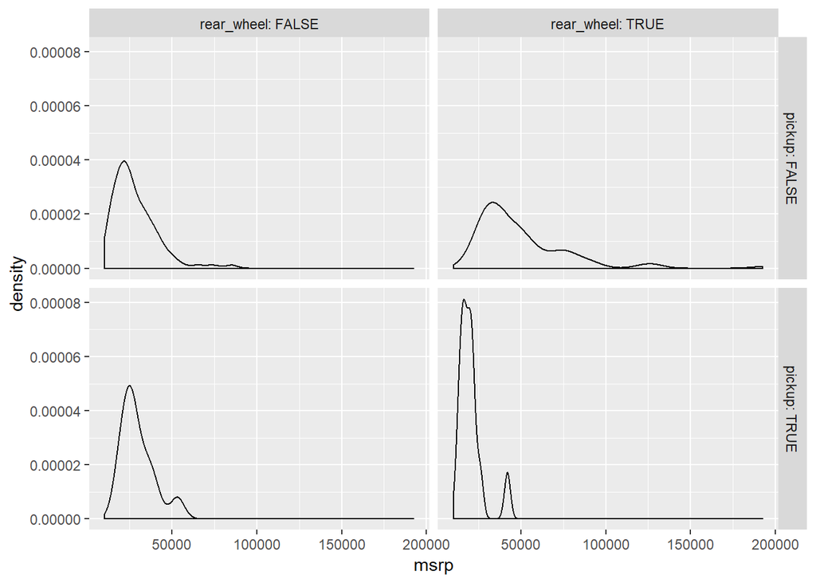

```r
ggplot(cars, aes(x = msrp)) +
  geom_density() +
  facet_grid(pickup ~ rear_wheel, labeller = label_both)
```

```r
table(cars$rear_wheel, cars$pickup)
```

```
##
##         FALSE TRUE
##   FALSE   306   12
##   TRUE     98   12
```

second column rear_wheel true shows that we have fewer cars with rear_wheel

Higner dimensional plots Anything that can be discern visually, things like - shape - size - color - pattern - movement - relative location, x-coordiate y-coordinate these can be mapped to a variable and plot alongside other variables

## 5.1 3 variable plot

Faceting is a valuable technique for looking at several conditional distributions at the same time.

If the faceted distributions are laid out in a grid, you can consider the association between a variable and two others. One on the rows of the grid and the other on the columns.

Using common_cyl create a histogram of hwy_mpg faceted on both ncyl and suv

Add a title to your plot to indicate what variables are being faceted on.

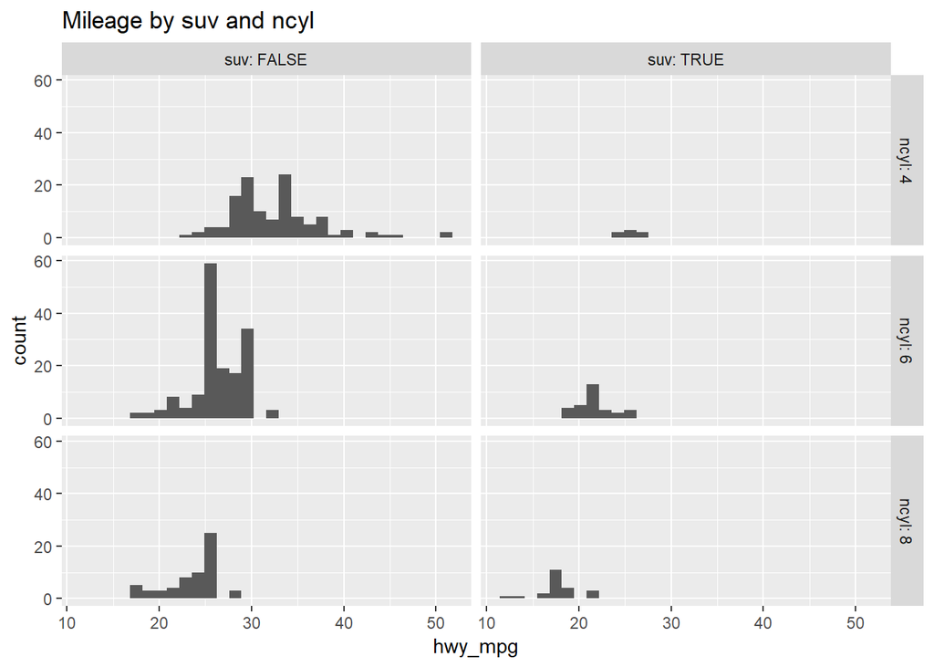

```r
common_cyl %>% ggplot(aes(x = hwy_mpg)) +
  geom_histogram() +
  facet_grid(ncyl~suv, labeller = label_both) +
  ggtitle("Mileage by suv and ncyl")
```

## 5.2 Interpret 3 var plot

Which of the following interpretations of the plot is valid?

Possible Answers Across both SUVs and non-SUVs, mileage tends to decrease as the number of cylinders increases. (ans)

There are more SUVs than non-SUVs across all cylinder types.

There is more variability in 6-cylinder non-SUVs than in any other type of car.

# 6 Exploratory Data Analysis of life dataset

```r
glimpse(life)
```

```
## Observations: 81,691
## Variables: 10
## $ State                                    <fct> Alabama, Alabama, Ala...
## $ County                                   <fct> Autauga County, Baldw...
## $ fips                                     <int> 1001, 1003, 1005, 100...
## $ Year                                     <int> 1985, 1985, 1985, 198...
## $ Female.life.expectancy..years.           <dbl> 77.0, 78.8, 76.0, 76....
## $ Female.life.expectancy..national..years. <dbl> 77.8, 77.8, 77.8, 77....
## $ Female.life.expectancy..state..years.    <dbl> 76.9, 76.9, 76.9, 76....
## $ Male.life.expectancy..years.             <dbl> 68.1, 71.1, 66.8, 67....
## $ Male.life.expectancy..national..years.   <dbl> 70.8, 70.8, 70.8, 70....
## $ Male.life.expectancy..state..years.      <dbl> 69.1, 69.1, 69.1, 69....
```

```r
fem.x = head(round(life$Female.life.expectancy..years.), 11)

fem.x
```

```
##  [1] 77 79 76 77 79 75 77 77 77 78 77
```

```r
# Typical measures of center: mean, median, mode

# average value
mean(fem.x)
```

```
## [1] 77.2
```

```r
# median is the middle value in the assorted data sort
median(fem.x)
```

```
## [1] 77
```

```r
# mode is simply the most common observation in the data set
# what does mode function return?
mode(fem.x)
```

```
## [1] "numeric"
```

```r
# Use the table function with one variable

table(fem.x)
```

```
## fem.x
## 75 76 77 78 79
##  1  1  6  1  2
```

*77 is the most occuring value*

Note: Imp Here both, median and mode are same. But thats often not the case.

The mean can be thought of as tha balance point of the data. and it tends to be drawn at the longer tail of the distribution. This highlights an important feature of the mean - its sensitivity to extreme values - for this reason when working with skewed distributions, median is a more appropriate measure of centre.

Now that we have some sensible measures of center, we can answer questions like - is the typical life expectancy on the west coast similar to the life expectancy in the rest of the country?

```r
# county dataset in openintro or gapminder

library(openintro)
glimpse(county)
```

```
## Observations: 3,143
## Variables: 10
## $ name          <fct> Autauga County, Baldwin County, Barbour County, ...
## $ state         <fct> Alabama, Alabama, Alabama, Alabama, Alabama, Ala...
## $ pop2000       <dbl> 43671, 140415, 29038, 20826, 51024, 11714, 21399...
## $ pop2010       <dbl> 54571, 182265, 27457, 22915, 57322, 10914, 20947...
## $ fed_spend     <dbl> 6.07, 6.14, 8.75, 7.12, 5.13, 9.97, 9.31, 15.44,...
## $ poverty       <dbl> 10.6, 12.2, 25.0, 12.6, 13.4, 25.3, 25.0, 19.5, ...
## $ homeownership <dbl> 77.5, 76.7, 68.0, 82.9, 82.0, 76.9, 69.0, 70.7, ...
## $ multiunit     <dbl> 7.2, 22.6, 11.1, 6.6, 3.7, 9.9, 13.7, 14.3, 8.7,...
## $ income        <dbl> 24568, 26469, 15875, 19918, 21070, 20289, 16916,...
## $ med_income    <dbl> 53255, 50147, 33219, 41770, 45549, 31602, 30659,...
```

```r
unique(county$state)
```

```
##  [1] Alabama              Alaska               Arizona
##  [4] Arkansas             California           Colorado
##  [7] Connecticut          Delaware             District of Columbia
## [10] Florida              Georgia              Hawaii
## [13] Idaho                Illinois             Indiana
## [16] Iowa                 Kansas               Kentucky
## [19] Louisiana            Maine                Maryland
## [22] Massachusetts        Michigan             Minnesota
## [25] Mississippi          Missouri             Montana
## [28] Nebraska             Nevada               New Hampshire
## [31] New Jersey           New Mexico           New York
## [34] North Carolina       North Dakota         Ohio
## [37] Oklahoma             Oregon               Pennsylvania
## [40] Rhode Island         South Carolina       South Dakota
## [43] Tennessee            Texas                Utah
## [46] Vermont              Virginia             Washington
## [49] West Virginia        Wisconsin            Wyoming
## 51 Levels: Alabama Alaska Arizona Arkansas California ... Wyoming
```

```r
unique(life$State)
```

```
##  [1] Alabama              Alaska               ALASKA
##  [4] Arizona              Arkansas             California
##  [7] COLORADO             Colorado             Connecticut
## [10] Delaware             District of Columbia Florida
## [13] Georgia              Hawaii               HAWAII
## [16] Idaho                Illinois             Indiana
## [19] Iowa                 Kansas               Kentucky
## [22] Louisiana            Maine                Maryland
## [25] Massachusetts        Michigan             Minnesota
## [28] Mississippi          Missouri             Montana
## [31] Nebraska             Nevada               New Hampshire
## [34] New Jersey           New Mexico           New York
## [37] North Carolina       North Dakota         Ohio
## [40] Oklahoma             Oregon               Pennsylvania
## [43] Rhode Island         South Carolina       South Dakota
## [46] Tennessee            Texas                Utah
## [49] Vermont              Virginia             Washington
## [52] West Virginia        Wisconsin            Wyoming
## 54 Levels: Alabama Alaska ALASKA Arizona Arkansas California ... Wyoming
```

```r
# Let's start by creating a new variable
life= life %>%
  mutate(west_coast = State %in%
           c("California","Oregon", "Washington"))

county = county %>%
  mutate(west_coast = state %in%
           c("California","Oregon", "Washington"))

names(life)
```

```
##  [1] "State"
##  [2] "County"
##  [3] "fips"
##  [4] "Year"
##  [5] "Female.life.expectancy..years."
##  [6] "Female.life.expectancy..national..years."
##  [7] "Female.life.expectancy..state..years."
##  [8] "Male.life.expectancy..years."
##  [9] "Male.life.expectancy..national..years."
## [10] "Male.life.expectancy..state..years."
## [11] "west_coast"
```

```r
names(county)
```

```
##  [1] "name"          "state"         "pop2000"       "pop2010"
##  [5] "fed_spend"     "poverty"       "homeownership" "multiunit"
##  [9] "income"        "med_income"    "west_coast"
```

```r
head(life$west_coast)
```

```
## [1] FALSE FALSE FALSE FALSE FALSE FALSE
```

```r
str(life$west_coast)
```

```
##  logi [1:81691] FALSE FALSE FALSE FALSE FALSE FALSE ...
```

```r
unique(life$west_coast)
```

```
## [1] FALSE  TRUE
```

```r
# mean and median for west_coast and non west_coast states
# this is done using group_by and summarize


life %>%
  group_by(west_coast) %>%
  summarise(mean(Female.life.expectancy..years.),
            median(Female.life.expectancy..years.))
```

```
## # A tibble: 2 x 3
##   west_coast `mean(Female.life.expectancy.~ `median(Female.life.expectancy~
##   <lgl>                               <dbl>                           <dbl>
## 1 FALSE                                78.7                            78.8
## 2 TRUE                                 79.6                            79.5
```

```r
# To understand group_by
# see the summarize function without group_by then group_by

life %>%
  slice(240:247) %>%
  summarize(mean(Female.life.expectancy..years.))
```

```
##   mean(Female.life.expectancy..years.)
## 1                                 78.8
```

```r
life %>%
  slice(240:247) %>%
  group_by(west_coast) %>%
  summarize(mean(Female.life.expectancy..years.))
```

```
## # A tibble: 2 x 2
##   west_coast `mean(Female.life.expectancy..years.)`
##   <lgl>                                       <dbl>
## 1 FALSE                                        79.4
## 2 TRUE                                         77.9
```

## 6.1 Choice of center measure

The choice of measure for center can have a dramatic impact on what we consider to be a typical observation, so it is important that you consider the shape of the distribution before deciding on the measure.

Which set of measures of central tendency would be worst for describing the two distributions shown here?

A - has typical bell curve shaped distribution, no skews B - has a peak on left side indicating modal value and is highly skewed on right

Possible Answers A: mode, B: median

A: mean, B: mode ( B can’t be mean as mean is sensitive to skew, aslo not median because the distribution is not divided into equal halves, mode is good as there is peak in the distribution corresponding to mode)

A: median, B: mean

A: median, B: median

Calculate center measures - throughout this chapter, you will use data from gapminder which tracks demographic data in countries of the world over time. To learn more about it, you can bring up the help file with ?gapminder

For this exercise, focus on how the life expectancy differs from continent to continent. This requires that you conduct your analysis not at the country level but aggregated up to the continental level.

This is made possible by group_by() and summarize(), a very powerful syntax for carrying out the same analysis on different subsets of the full dataset.

```r
library(gapminder)
glimpse(gapminder)
```

```
## Observations: 1,704
## Variables: 6
## $ country   <fct> Afghanistan, Afghanistan, Afghanistan, Afghanistan, ...
## $ continent <fct> Asia, Asia, Asia, Asia, Asia, Asia, Asia, Asia, Asia...
## $ year      <int> 1952, 1957, 1962, 1967, 1972, 1977, 1982, 1987, 1992...
## $ lifeExp   <dbl> 28.8, 30.3, 32.0, 34.0, 36.1, 38.4, 39.9, 40.8, 41.7...
## $ pop       <int> 8425333, 9240934, 10267083, 11537966, 13079460, 1488...
## $ gdpPercap <dbl> 779, 821, 853, 836, 740, 786, 978, 852, 649, 635, 72...
```

```r
#Create a dataset called gap2007 that contains only data from the year 2007.
str(gapminder$year)
```

```
##  int [1:1704] 1952 1957 1962 1967 1972 1977 1982 1987 1992 1997 ...
```

```r
length(unique(gapminder$year))
```

```
## [1] 12
```

```r
unique(gapminder$year)
```

```
##  [1] 1952 1957 1962 1967 1972 1977 1982 1987 1992 1997 2002 2007
```

```r
gap2007 = gapminder %>%
  filter(year == 2007 )


glimpse(gap2007)
```

```
## Observations: 142
## Variables: 6
## $ country   <fct> Afghanistan, Albania, Algeria, Angola, Argentina, Au...
## $ continent <fct> Asia, Europe, Africa, Africa, Americas, Oceania, Eur...
## $ year      <int> 2007, 2007, 2007, 2007, 2007, 2007, 2007, 2007, 2007...
## $ lifeExp   <dbl> 43.8, 76.4, 72.3, 42.7, 75.3, 81.2, 79.8, 75.6, 64.1...
## $ pop       <int> 31889923, 3600523, 33333216, 12420476, 40301927, 204...
## $ gdpPercap <dbl> 975, 5937, 6223, 4797, 12779, 34435, 36126, 29796, 1...
```

```r
#Using gap2007 calculate the mean and median life expectancy for each continent.

str(gapminder$continent)
```

```
##  Factor w/ 5 levels "Africa","Americas",..: 3 3 3 3 3 3 3 3 3 3 ...
```

```r
unique(gapminder$continent)
```

```
## [1] Asia     Europe   Africa   Americas Oceania
## Levels: Africa Americas Asia Europe Oceania
```

```r
gap2007 %>%
  group_by(continent) %>%
  summarise(mean(lifeExp), median(lifeExp))
```

```
## # A tibble: 5 x 3
##   continent `mean(lifeExp)` `median(lifeExp)`
##   <fct>               <dbl>             <dbl>
## 1 Africa               54.8              52.9
## 2 Americas             73.6              72.9
## 3 Asia                 70.7              72.4
## 4 Europe               77.6              78.6
## 5 Oceania              80.7              80.7
```

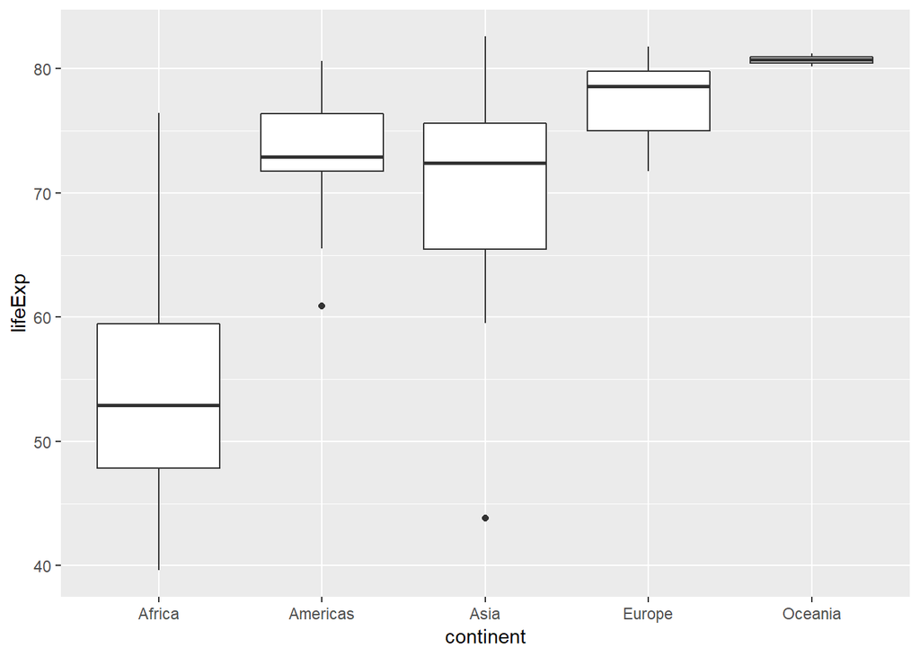

```r
# Confirm the trends that you see in the medians by generating side-by-side box plots
# of life expectancy for each continent

gap2007 %>%
  ggplot(aes(x = continent, y = lifeExp)) +
  geom_boxplot()
```

```r
life.x = head(gapminder$lifeExp, 11)
life.x
```

```
##  [1] 28.8 30.3 32.0 34.0 36.1 38.4 39.9 40.8 41.7 41.8 42.1
```

```r
life.x - mean(life.x)
```

```
##  [1] -8.101 -6.570 -4.905 -2.882 -0.814  1.536  2.952  3.920  4.772  4.861
## [11]  5.227
```

```r
fem.x
```

```
##  [1] 77 79 76 77 79 75 77 77 77 78 77
```

```r
fem.x - mean(fem.x)
```

```
##  [1] -0.182  1.818 -1.182 -0.182  1.818 -2.182 -0.182 -0.182 -0.182  0.818
## [11] -0.182
```

As you can see some have positive difference and some negative - let’s reduce them to single level of variability - so let’s add up all the variabilities

```r
sum(life.x - mean(life.x))
```

```
## [1] 0.00000000000000355
```

```r
sum(fem.x - mean(fem.x))
```

```
## [1] -0.0000000000000568
```

sum of differences is essentially it is zero, which is not true because there are differences, it is because the positive negative difference cancel out each other - to fix this we square the differences

```r
sum((life.x - mean(life.x))^2)
```

```
## [1] 242
```

```r
sum((fem.x - mean(fem.x))^2)
```

```
## [1] 13.6
```

This new measure of variability is better - but it has an undesirable property that it gets bigger as you add more data to it - to fix this problem you can divide the sum by the number of observations

```r
length(life.x)
```

```
## [1] 11
```

```r
sum((life.x - mean(life.x))^2)/length(life.x)
```

```
## [1] 22
```

```r
sum((fem.x - mean(fem.x))^2)/length(fem.x)
```

```
## [1] 1.24
```

## 6.2 {What is sample variance and sample standard deviation?}

So this is starting to look like a useful measure - you find the center of the data - then find the difference between the observations and that mean - then square and divide by the number of observations(n) - if you divide by n-1, then you are left with what is called the sample variance - one of the most useful measures of a spread of distribution - in R this statistic is wrapped up in a function var for variance - another useful measure is the square root of this measure which is called the sample standard deviation or just sd in R - the convenient thing about sd is that once computed it is in the same unit as the original data { var is square and this is sqrt so you get back the original unit of measure}

## 6.3 { What is IQR - Inter Quartile Range}

- there are two more measures of spread that are good to know about
- the inter quartile range or IQR is the distance between the two numbers that cut off the middle fifty percent of the data
- this should sound familiar from the discussion of boxplots
- the height of the box is exactly IQR
- we can get the first and third quartile from summary function and take their difference or use the built in IQR function

## 6.4 {Range}

- the final measure is simply the range of the data
- the distance between the max and min
- you can use max, min function to get range or diff(range(x))

## 6.5 {Which is the best measure}

- For any dataset, you can compute all four of these statistics
- but which ones are the most meaningful
- the most commonly used is the standard deviation sd
- so that is often a good place to start
- but what happens if data has some extreme observations
- let’s say there was lifexp of 97 for a particular state
- mean var sd are sensitive to extreme values as measure of center
- range is completely affected by the extreme values, hence it is not usually a good measure of center
- IQR does not change though, therefore IQR is a good measure when data is skewed or has extreme observations

```r
# Sample variance

sum((life.x - mean(life.x))^2)/(length(life.x) - 1)
```

```
## [1] 24.2
```

```r
var(life.x)
```

```
## [1] 24.2
```

```r
sqrt(var(life.x))
```

```
## [1] 4.92
```

```r
sd(life.x)
```

```
## [1] 4.92
```

```r
sum((fem.x - mean(fem.x))^2)/(length(fem.x) - 1)
```

```
## [1] 1.36
```

```r
var(fem.x)
```

```
## [1] 1.36
```

```r
sqrt(var(fem.x))
```

```
## [1] 1.17
```

```r
sd(fem.x)
```

```
## [1] 1.17
```

```r
summary(life.x)
```

```
##    Min. 1st Qu.  Median    Mean 3rd Qu.    Max.
##    28.8    33.0    38.4    36.9    41.2    42.1
```

```r
IQR(life.x)
```

```
## [1] 8.24
```

```r
diff(range(life.x))
```

```
## [1] 13.3
```

```r
summary(fem.x)
```

```
##    Min. 1st Qu.  Median    Mean 3rd Qu.    Max.
##    75.0    77.0    77.0    77.2    77.5    79.0
```

```r
IQR(fem.x)
```

```
## [1] 0.5
```

```r
diff(range(fem.x))
```

```
## [1] 4
```

**Which set of measures of spread would be WORST for describing** **the two distributions shown here?**

A - bell shaped curve B - lhs has peak and rhs has extreme valuem, hence skewed

{A is normal distribution hence SD is good B is skewed hence mean, var, sd, range will all be affected by the extreme values, IQR is not affected by these extreme values helps so worst measure would anything other than these}

A: IQR, B: IQR A: SD, B: IQR A: Variance, B: Range (answer) Range is not good for skewed data

## 6.6 Calculate spread measures

Let’s extend the powerful group_by() and summarize() syntax to measures of spread. If you’re unsure whether you’re working with symmetric or skewed distributions, it’s good idea to consider a robust measure like IQR in addition to the usual measures of variance or standard deviation

```r
names(gap2007)
```

```
## [1] "country"   "continent" "year"      "lifeExp"   "pop"       "gdpPercap"
```

```r
nrow(gap2007)
```

```
## [1] 142
```

```r
glimpse(gap2007)
```

```
## Observations: 142
## Variables: 6
## $ country   <fct> Afghanistan, Albania, Algeria, Angola, Argentina, Au...
## $ continent <fct> Asia, Europe, Africa, Africa, Americas, Oceania, Eur...
## $ year      <int> 2007, 2007, 2007, 2007, 2007, 2007, 2007, 2007, 2007...
## $ lifeExp   <dbl> 43.8, 76.4, 72.3, 42.7, 75.3, 81.2, 79.8, 75.6, 64.1...
## $ pop       <int> 31889923, 3600523, 33333216, 12420476, 40301927, 204...
## $ gdpPercap <dbl> 975, 5937, 6223, 4797, 12779, 34435, 36126, 29796, 1...
```

For each continent in gap2007 summarize life expectancies using sd() the IQR and the count of countries (n) No need to name the new columns produced here. The n() function within you summarize() call does not take any arguments.

```r
gap2007 %>%
  group_by(continent) %>%
  summarise(sd(lifeExp), IQR(lifeExp), n())
```

```
## # A tibble: 5 x 4
##   continent `sd(lifeExp)` `IQR(lifeExp)` `n()`
##   <fct>             <dbl>          <dbl> <int>
## 1 Africa            9.63          11.6      52
## 2 Americas          4.44           4.63     25
## 3 Asia              7.96          10.2      33
## 4 Europe            2.98           4.78     30
## 5 Oceania           0.729          0.516     2
```

Graphically compare the spread of these distributions by constructing overlaid density plots of life expectancy broken down by continent.

- overlaid implies not grids but overlay in same graph
- so no need to use facet_wrap or facet_grid, just fill by continent

x-axis numerical variable lifeExp overlaid by continent, fill by categorical variable continent

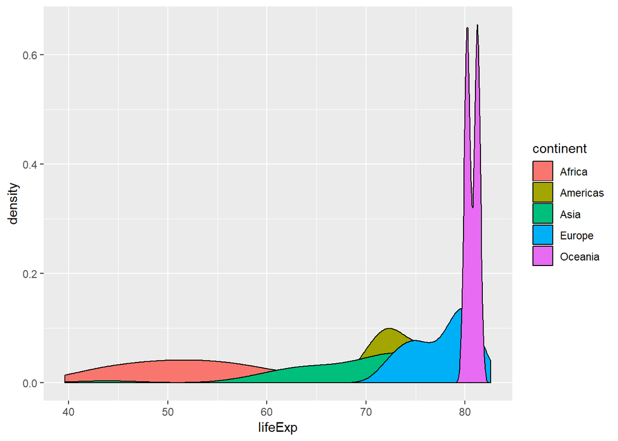

```r
ggplot(gap2007, aes(x=lifeExp, fill = continent)) +
  geom_density()
```

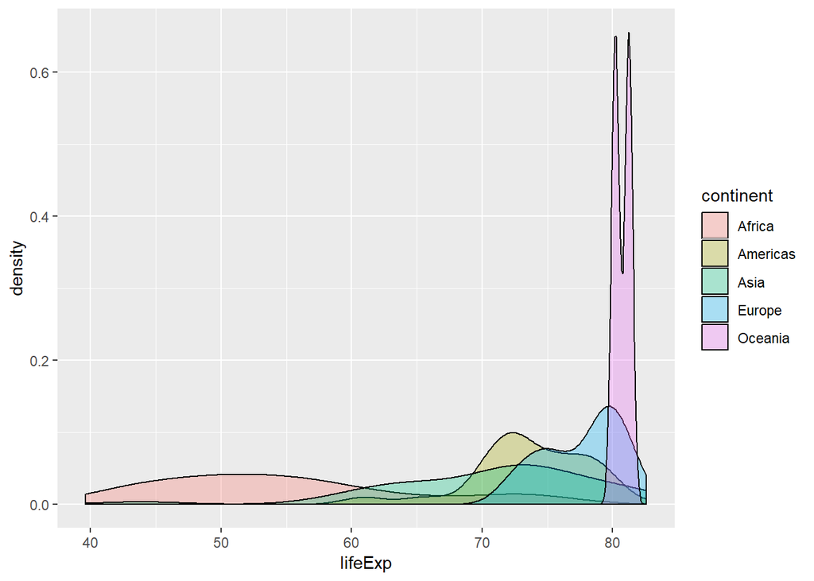

```r
#{ lighten up the grapbh, alpha is to set transparency}

ggplot(gap2007, aes(x=lifeExp, fill = continent)) +
  geom_density(alpha = 0.3)
```

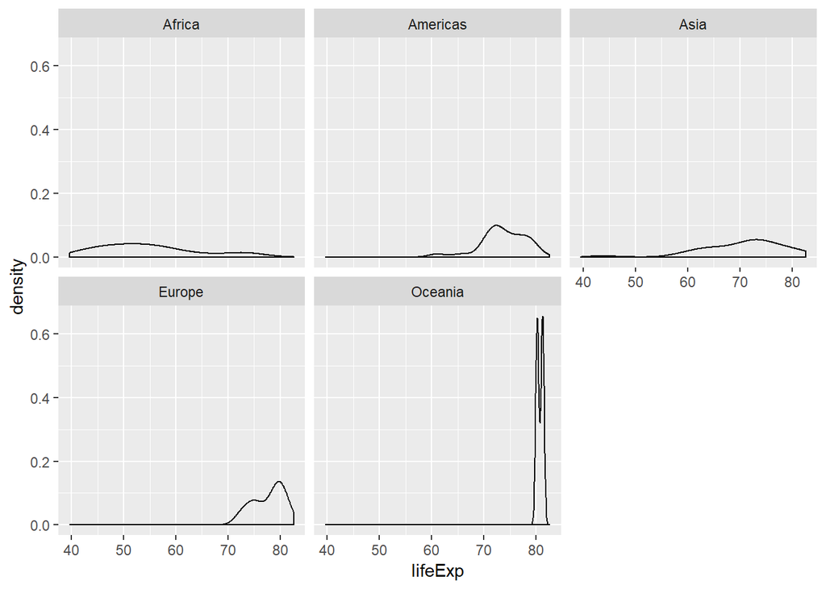

```r
# facet_wrap vs facet_grid

# facet_wrap creates different graps - separate x,y axis
ggplot(gap2007, aes(x=lifeExp)) +
  geom_density(alpha = 0.3) +
  facet_wrap(~continent)
```

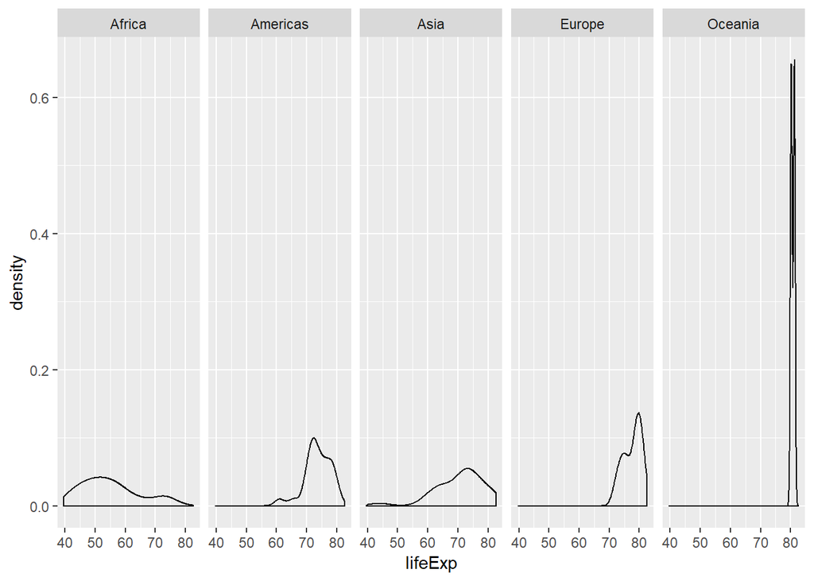

```r
# facet_grid splits the graph into grids keeping the original
# x,y axis
ggplot(gap2007, aes(x=lifeExp)) +
  geom_density(alpha = 0.3) +
  facet_grid(~continent)
```

Choose measures for center and spread

Consider the density plots shown here.

What are the most appropriate measures to describe their centers and spreads? In this exercise, you’ll select the measure and then calculate them.

Using the shapes of the density plots, calculate the most appropriate measures of center and spread for the following

The distribution of life expectancy in the countries of the Americas. Note you’ll need to appy a filter here.

The distribution of country populations across the entire gap2007 dataset.

```r
# Compute stats for lifeExp in Americas
gap2007 %>%
  filter(continent == 'Americas') %>%
  summarize(mean(lifeExp),
            sd(lifeExp))
```

```
## # A tibble: 1 x 2
##   `mean(lifeExp)` `sd(lifeExp)`
##             <dbl>         <dbl>
## 1            73.6          4.44
```

```r
# Compute stats for entire population
gap2007 %>%
  summarize(median(pop),
            IQR(pop))
```

```
## # A tibble: 1 x 2
##   `median(pop)` `IQR(pop)`
##           <dbl>      <dbl>
## 1      10517531  26702008.
```

Excellent! Like mean and standard deviation, median and IQR measure the central tendency and spread, respectively, but are robust to outliers and non-normal data.

# 7 Shapes and transformations

- there are generally four characteristics of distribution that are of interest
- the first two we have covered already
- the center and spread or variability of the distribution
- the third is the shape of the distribution, which can be described in terms of modality and the skew

# 8 Modality - Unimodal Bimodal

- Modality of the distribution is the number of prominent humps that show up in the distribution
- if there is a single mode as in the case of bell-curve, it is called unimodal and if there are two humps it is called bimodal and multimodal if more than two humps
- and there is one last case when there is no distinct mode because the distribution is flat across all values, it is referred to as uniform

# 9 Skew - Right-skewed Left-skewed Symmetric

- the other aspect that concerns the shape of distribution is its skew
- if the distribution has a long tail that stretches out to the right, it is referred to as right-skewed
- and if that long tail stretches out to the left, it is reffered to as left-skewed
- if neither tail is longer than the other, the distribution is called symmetric

# 10 Shape of income (life dataset)

An overlay density plot with income on x-axis filling the two curves based on whether they’re on the west coast or not, to make the density plot lighter we use make the colours transparent so that we can see where they overlap - that is where the incomes overlap

```r
names(life)
```

```
##  [1] "State"
##  [2] "County"
##  [3] "fips"
##  [4] "Year"
##  [5] "Female.life.expectancy..years."
##  [6] "Female.life.expectancy..national..years."
##  [7] "Female.life.expectancy..state..years."
##  [8] "Male.life.expectancy..years."
##  [9] "Male.life.expectancy..national..years."
## [10] "Male.life.expectancy..state..years."
## [11] "west_coast"
```

```r
str(county$income)
```

```
##  num [1:3143] 24568 26469 15875 19918 21070 ...
```

```r
"
x-axis numerical variable income, density plot overlaid by categorical
variable west-coast
"
```

```
## [1] "\nx-axis numerical variable income, density plot overlaid by categorical\nvariable west-coast\n"
```

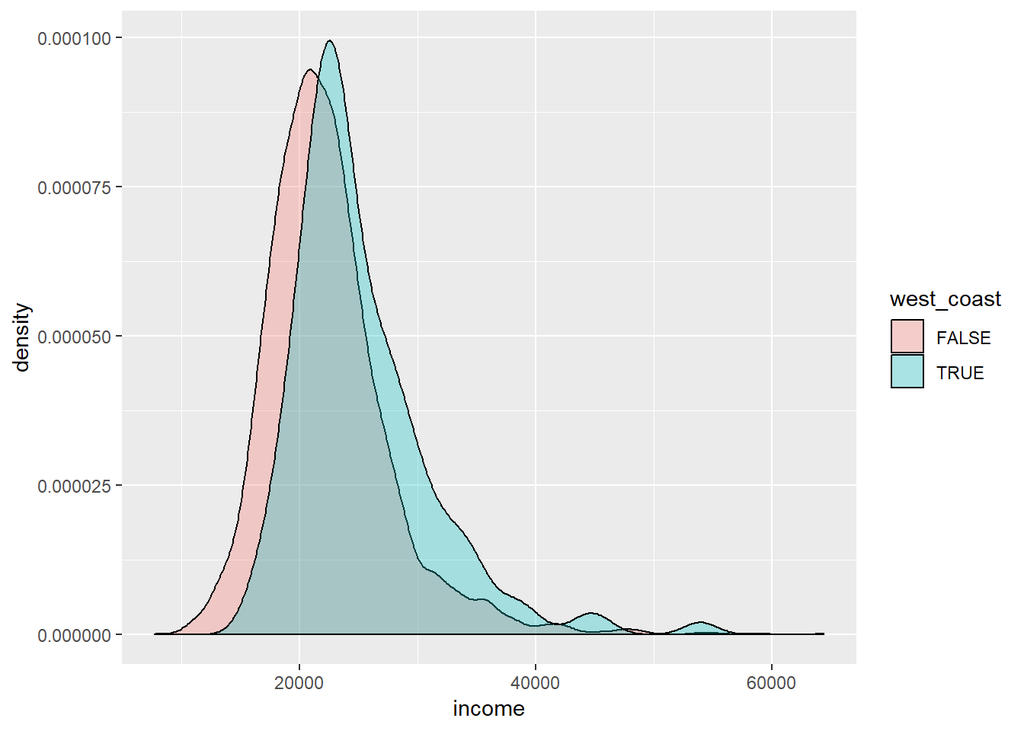

```r
ggplot(county, aes(x = income, fill = west_coast)) +
  geom_density(alpha = 0.3)
```

Each distribution is unimode - it is difficult to compare both these distributions as they’re both heavily right skewed - that is there are few conties in each group that have very high incomes - one way to remedy this is to construct a plot of a transformed version of this plot - since income has a very high right skew either the square root or log transform will do a good job of drawing in the tail and spreading out the lower values so that we can see what’s going on - the result is a picture which is bit better to interpret

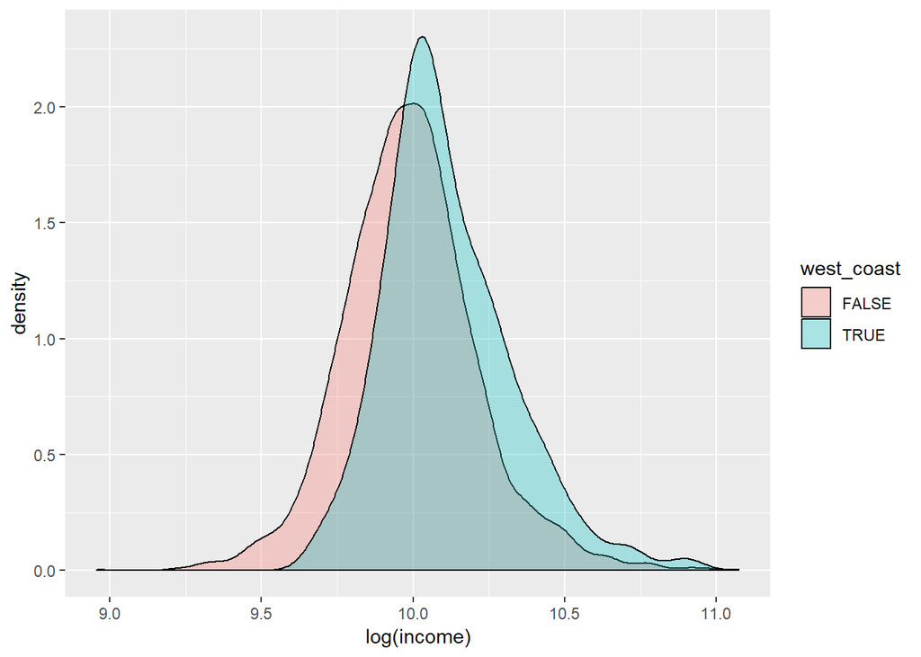

```r
# scaling income values using log

ggplot(county, aes(x = log(income), fill = west_coast)) +
  geom_density(alpha = 0.3)
```

Income in west coast counties is indeed greater than in the rest of the country

Let’s explore the gapminder data

Transformations Highly skewed distributions can make it very difficult to learn anything from a visualization. Transformations can be helpful in revealing the more subtle structure

Here you’ll focus on the population variable, which exhibits strong right skew and transform it with the natural logarithm function (log() in R)

Using the gap2007 data:

```r
# Create a density plot of the population variable.

names(gap2007)
```

```
## [1] "country"   "continent" "year"      "lifeExp"   "pop"       "gdpPercap"
```

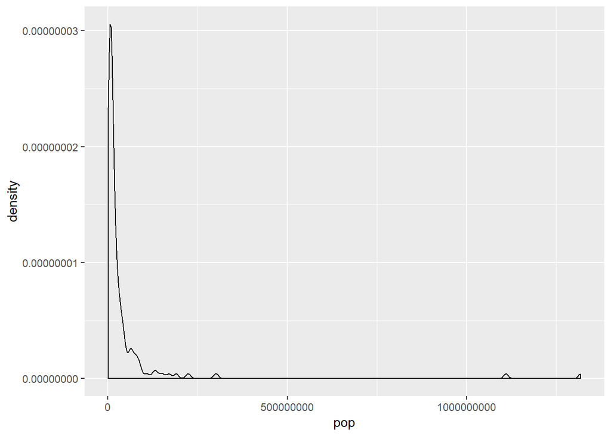

```r
gap2007 %>% ggplot(aes(x = pop)) +
  geom_density()
```

```r
#Mutate a new column called log_pop that is the natural
#log of the population and save it back into gap2007.

gap2007 = gap2007 %>%
  mutate(pop_log = log(pop))

names(gap2007)
```

```
## [1] "country"   "continent" "year"      "lifeExp"   "pop"       "gdpPercap"
## [7] "pop_log"
```

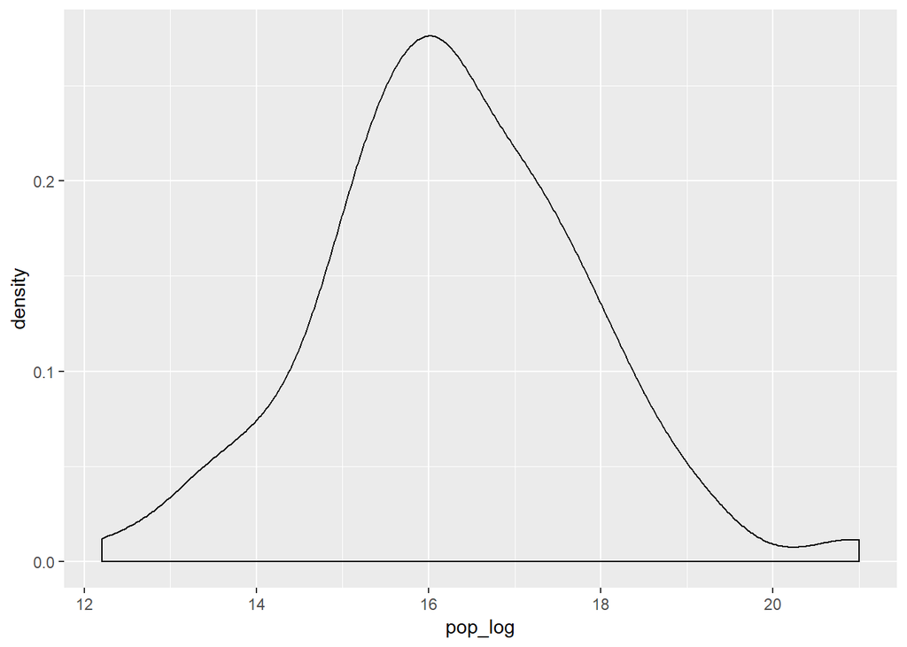

```r
# Create a density plot of your transformed variable
gap2007 %>% ggplot(aes(x = pop_log)) +
  geom_density()
```

# 11 Outliers

- we have discussed three different aspects of distribution that are important to note when conducting an exploratory data analysis
1. Center
2. Variability
3. Shape
- and the final thing to look out for are
4. Outliers
- these are observations that have extreme values far from the bulk of distribution
- they’re often very interesting cases but they’re also good to know about before proceding with the analysis
- we saw few extreme values when we plotting distributions of incomes of counties on west coast
- what do we make of this blip of counties
- one thing we can do is, try this as a box plot

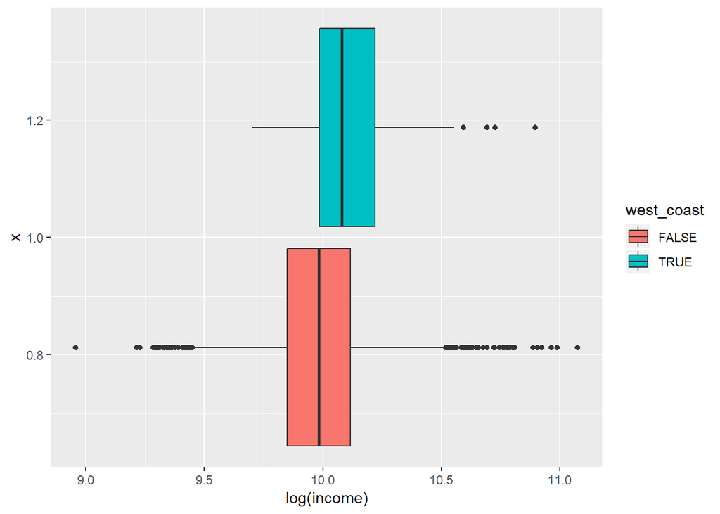

```r
ggplot(county, aes( x= 1, y = log(income), fill = west_coast)) +
  geom_boxplot() +
  coord_flip()
```

- the box plot reveals that there are many outliers both in west coast and non west coast counties
- so why was the blip (slight bump on the right side of distribution) more apparent in the case of west coast?
- it has something to do with the sample size
- there are far fewer counties in west coast so these few outliers had an outsized effect on the density plot
- in the case of the non-west coast group there are many many more counteis that were able to wash out the effect of these outliers on the density plot

Indicating outliers - it is often useful to consider outliers separately from the data

```r
names(county)
```

```
##  [1] "name"          "state"         "pop2000"       "pop2010"
##  [5] "fed_spend"     "poverty"       "homeownership" "multiunit"
##  [9] "income"        "med_income"    "west_coast"
```

```r
summary(county$income)
```

```
##    Min. 1st Qu.  Median    Mean 3rd Qu.    Max.
##    7772   19030   21773   22505   24814   64381
```

create outlier income indicator for any threshold income, say 45000 usd Below mutate assign true to the new variable if condition is true else false

```r
county = county %>%
  mutate(is_outlier = income > 45000)

names(county)
```

```
##  [1] "name"          "state"         "pop2000"       "pop2010"
##  [5] "fed_spend"     "poverty"       "homeownership" "multiunit"
##  [9] "income"        "med_income"    "west_coast"    "is_outlier"
```

```r
# observations with outlier income
county %>%
  filter(is_outlier) %>%
  arrange(desc(income)) %>%
  select(name, state, income, is_outlier)
```

```
##                    name         state income is_outlier
## 1         Pitkin County      Colorado  64381       TRUE
## 2       New York County      New York  59149       TRUE
## 3      Arlington County      Virginia  57724       TRUE
## 4     Falls Church city      Virginia  55389       TRUE
## 5       Alexandria city      Virginia  54345       TRUE
## 6          Marin County    California  53940       TRUE
## 7      Nantucket County Massachusetts  53410       TRUE
## 8     Los Alamos County    New Mexico  49474       TRUE
## 9        Fairfax County      Virginia  49001       TRUE
## 10     Hunterdon County    New Jersey  48489       TRUE
## 11     Fairfield County   Connecticut  48295       TRUE
## 12   Westchester County      New York  47814       TRUE
## 13        Morris County    New Jersey  47342       TRUE
## 14    Montgomery County      Maryland  47310       TRUE
## 15      Somerset County    New Jersey  47067       TRUE
## 16       Mineral County      Colorado  46358       TRUE
## 17 San Francisco County    California  45478       TRUE
## 18       Loudoun County      Virginia  45356       TRUE
## 19        Howard County      Maryland  45294       TRUE
```

We see the highest income is in Pitkin County of Colorado state

Plotting without outliers - first filter out those counties that are not outliers and pass this to ggplot using %>% operator

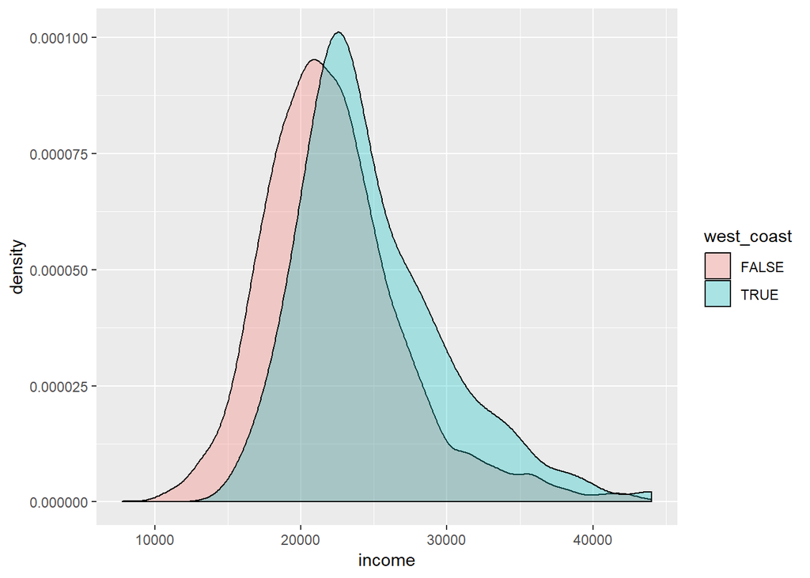

```r
# Overlay density plot of incomes for west_coast
# and non west_coast without outliers
county %>%
  filter(!is_outlier) %>%
  ggplot(aes(x = income, fill = west_coast)) +
  geom_density(alpha = 0.3)
```

The result is a plot that focuses much more on the body of the distribution. - compare this with the original plot which was dominated by the right skew caused the the extreme values - non of these plots is right or wrong, they both tell us different stories about the structure in this data, both of which are valuable

# 12 Exploring outliers in gapminder data

Identify outliers Consider the distribution shown here of the life expectancies of the countries in Asia. The box plot identifies one clear outlier: a country with a notably low life expectancy. Do you have a guess as to which country this might be? Test your guess in the console using either min() or filter() then proceed to building a plot with that country removed.

```r
names(gap2007)
```

```
## [1] "country"   "continent" "year"      "lifeExp"   "pop"       "gdpPercap"
## [7] "pop_log"
```

```r
gap_asia = gap2007 %>%
  filter(continent == 'Asia') %>%
  mutate(is_outlier = lifeExp < 50 )

names(gap_asia)
```

```
## [1] "country"    "continent"  "year"       "lifeExp"    "pop"
## [6] "gdpPercap"  "pop_log"    "is_outlier"
```

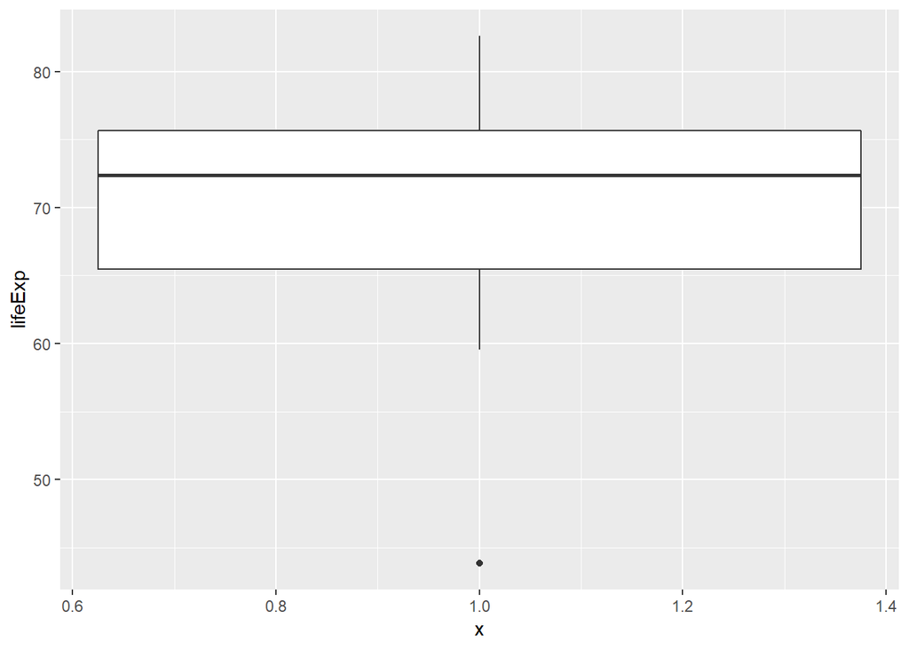

```r
gap_asia %>%
  ggplot(aes(x = 1, y = lifeExp)) +
  geom_boxplot()
```

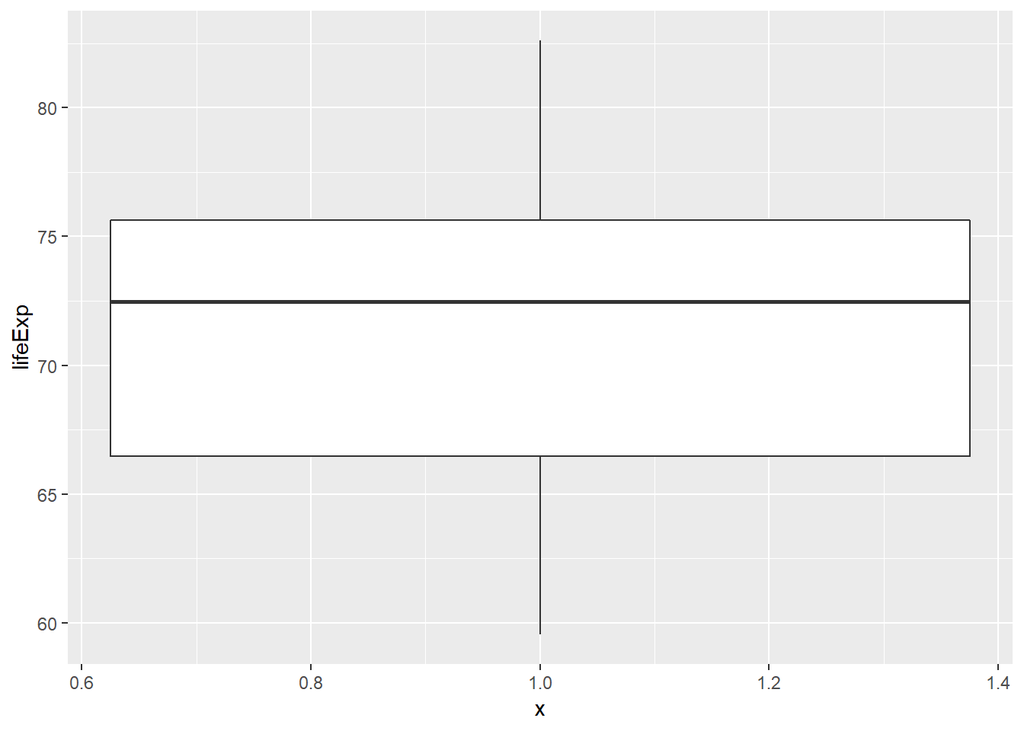

```r
gap_asia %>%
  filter(!is_outlier) %>%
  ggplot(aes(x = 1, y = lifeExp)) +
  geom_boxplot()
```